# GSEM factor analysis - theory-driven

AA, JP & AT

03 July, 2024

# Factor structure underlying substance use: Alternative theoretical models

Here I’m going to test different alternative models in the full set of chromosomes, created with LDSC, without the index event bias-correction. I plot results for models with decent overall fit.

## Bifactor models

Bifactor models are used to test if adding an extra general latent factor G (as in P for psychopathology) to the structure improves fit.

### EFA-based

First, the 4-factor structure identified with EFA is tested. The model shows excellent fit, although not all indicators load significantly on their factor. F1 seems superfluous, it is almost as general as G. This argues for a S-1 model where the first factor is dropped.

```r
load('data/mldsc_29May2023.14.TOT.RData')

bif <- '

G =~ NA*SMKCES + PACKYE + SMKDEP + CANDEP + COCDEP + OPIODEP + SMKAGE + ALCDEP + CANEV + CANFL + SMKINI + ALCCON + ALCFRQ + ALCP

F1 =~ NA*SMKCES + PACKYE + SMKDEP + ALCDEP + ALCFRQ + COCDEP + CANEV + SMKINI + SMKAGE
F2 =~ NA*CANDEP + COCDEP + OPIODEP + SMKAGE
F3 =~ NA*ALCDEP + ALCCON + ALCFRQ + ALCP
F4 =~ NA*CANEV + CANFL + SMKINI

G~~1*G
F1~~1*F1
F2~~1*F2
F3~~1*F3
F4~~1*F4

G ~~ 0*F1 + 0*F2 + 0*F3 + 0*F4

a>.001
CANEV~~a*CANEV

b>0.001
SMKAGE~~b*SMKAGE

c>-0.999
F1~~c*F2

d>-0.999
F1~~d*F4
'


#run the model
fit <- usermodel(ldscOut, estimation = "DWLS", model = bif, CFIcalc = TRUE)
```

```r
fitlabel <- paste0("CFI = ", round(fit$modelfit$CFI,3), ", SRMR = ", round(fit$modelfit$SRMR,3))
kable(fitlabel)
```

| x |
| --- |
| CFI = 0.986, SRMR = 0.05 |

**Click to expand table with model parameters**

```r
kable(fit$results)
```

|  | lhs | op | rhs | Unstand_Est | Unstand_SE | STD_Genotype | STD_Genotype_SE | STD_All | p_value |
| --- | --- | --- | --- | --- | --- | --- | --- | --- | --- |
| 55 | G | =~ | SMKCES | 0.2147046 | 0.00882502283115776 | 0.7988029 | 0.0330952858101609 | 0.7988030 | 0.0000000 |
| 53 | G | =~ | PACKYE | 0.2856856 | 0.0122483627104241 | 0.9472040 | 0.0397454029856641 | 0.9472040 | 0.0000000 |
| 56 | G | =~ | SMKDEP | 0.2535140 | 0.0312119862733955 | 0.7215883 | 0.0865993374784979 | 0.7215883 | 0.0000000 |
| 48 | G | =~ | CANDEP | 0.1333157 | 0.0432049472151988 | 0.4476201 | 0.144155439770193 | 0.4476203 | 0.0020310 |
| 51 | G | =~ | COCDEP | 0.3404360 | 0.0559001679044743 | 0.6257936 | 0.101519462489902 | 0.6257937 | 0.0000000 |
| 52 | G | =~ | OPIODEP | 0.1819281 | 0.0825237630211775 | 0.4105150 | 0.184578410956879 | 0.4105151 | 0.0274854 |
| 54 | G | =~ | SMKAGE | -0.0994070 | 0.0655708964730289 | -0.4609418 | 0.30021834965456 | -0.4579985 | 0.1295136 |
| 45 | G | =~ | ALCDEP | 0.2358812 | 0.0577053685193505 | 0.6238336 | 0.148894154732039 | 0.6238337 | 0.0000436 |
| 49 | G | =~ | CANEV | -0.0457548 | 0.0524502304370559 | -0.0778177 | 0.0922650725531351 | -0.0778177 | 0.3830194 |
| 50 | G | =~ | CANFL | 0.0202344 | 0.0242135993323819 | 0.0977053 | 0.114147841230761 | 0.0977052 | 0.4033454 |
| 57 | G | =~ | SMKINI | 0.1571091 | 0.0595043902932212 | 0.4598411 | 0.170067915857096 | 0.4598412 | 0.0082834 |
| 44 | G | =~ | ALCCON | 0.0957379 | 0.0119876331135624 | 0.3645776 | 0.0456220220057065 | 0.3645776 | 0.0000000 |
| 46 | G | =~ | ALCFRQ | -0.1032237 | 0.0105657806162121 | -0.3593818 | 0.0352393210043225 | -0.3593818 | 0.0000000 |
| 47 | G | =~ | ALCP | 0.0569082 | 0.0130270424298058 | 0.2374565 | 0.0540595927084295 | 0.2374565 | 0.0000125 |
| 19 | F1 | =~ | SMKCES | 0.0046740 | 0.0735331469163499 | -0.0234373 | 0.271839544690832 | -0.0234373 | 0.9493184 |
| 17 | F1 | =~ | PACKYE | -0.0086154 | 0.0977501891248002 | 0.0207463 | 0.322015878368044 | 0.0207463 | 0.9297676 |
| 20 | F1 | =~ | SMKDEP | -0.0624760 | 0.0915650315376371 | 0.1712714 | 0.258985768625289 | 0.1712714 | 0.4950409 |
| 13 | F1 | =~ | ALCDEP | -0.1297269 | 0.0597715326541146 | 0.3345583 | 0.157534040616138 | 0.3345583 | 0.0299782 |
| 14 | F1 | =~ | ALCFRQ | 0.0497303 | 0.0651776569981883 | -0.1670000 | 0.225551773031552 | -0.1670000 | 0.4454658 |
| 16 | F1 | =~ | COCDEP | -0.0021685 | 0.0938524222132846 | 0.0008712 | 0.170358764086181 | 0.0008712 | 0.9815665 |
| 15 | F1 | =~ | CANEV | 0.0348197 | 0.0812683415795641 | -0.0586620 | 0.140732408848497 | -0.0586620 | 0.6683211 |
| 21 | F1 | =~ | SMKINI | -0.1094244 | 0.0538315538301552 | 0.3124051 | 0.155789009839054 | 0.3124051 | 0.0420809 |
| 18 | F1 | =~ | SMKAGE | 0.1987202 | 0.0662266364739202 | -0.9246721 | 0.318394819892023 | -0.9187676 | 0.0026944 |
| 25 | F2 | =~ | CANDEP | 0.2057694 | 0.0503209103493618 | 0.6832996 | 0.168579560511577 | 0.6833000 | 0.0000433 |
| 26 | F2 | =~ | COCDEP | 0.2636150 | 0.0842809912614842 | 0.4812242 | 0.154627587855657 | 0.4812243 | 0.0017611 |
| 27 | F2 | =~ | OPIODEP | 0.3913137 | 0.0769652601754374 | 0.8715226 | 0.172734420396996 | 0.8715229 | 0.0000004 |
| 28 | F2 | =~ | SMKAGE | 0.0092491 | 0.070694188555657 | 0.0592884 | 0.339675457083573 | 0.0589098 | 0.8959074 |
| 32 | F3 | =~ | ALCDEP | 0.1891530 | 0.0254829838228836 | 0.4962150 | 0.0671942311615964 | 0.4962151 | 0.0000000 |
| 31 | F3 | =~ | ALCCON | 0.2205092 | 0.00970816530439337 | 0.8381732 | 0.0369660537987882 | 0.8381732 | 0.0000000 |
| 33 | F3 | =~ | ALCFRQ | 0.2256272 | 0.0103981775399176 | 0.7841444 | 0.0361179245204212 | 0.7841444 | 0.0000000 |
| 34 | F3 | =~ | ALCP | 0.1960763 | 0.00906028717156006 | 0.8151787 | 0.0377100802172036 | 0.8151787 | 0.0000000 |
| 36 | F4 | =~ | CANEV | 0.5404111 | 0.0418783479170578 | 0.9425588 | 0.0731523424717655 | 0.9425587 | 0.0000000 |
| 37 | F4 | =~ | CANFL | 0.1652146 | 0.0199219490014449 | 0.7796873 | 0.0940677331260252 | 0.7796869 | 0.0000000 |
| 38 | F4 | =~ | SMKINI | 0.1967197 | 0.0197484875547133 | 0.5686414 | 0.0575888112533579 | 0.5686415 | 0.0000000 |
| 6 | CANEV | ~~ | CANEV | 0.0466203 | 0.0255528538139334 | 0.1391592 | 0.0779697140452323 | 0.1391592 | 0.0680820 |
| 60 | SMKAGE | ~~ | SMKAGE | 0.0009999 | 0.00960538326170753 | 0.0010000 | 0.212502907627913 | 0.0010000 | 0.9170929 |
| 10 | F1 | ~~ | F2 | -0.5323619 | 0.262274508824348 | 0.5390739 | 0.265048610390646 | 0.5390739 | 0.0423780 |
| 12 | F1 | ~~ | F4 | -0.3328037 | 0.186096637056358 | 0.3352451 | 0.186093589581908 | 0.3352451 | 0.0737215 |
| 63 | SMKINI | ~~ | SMKINI | 0.0292366 | 0.00483397279126321 | 0.2484858 | 0.0406600743496152 | 0.2484858 | 0.0000000 |
| 61 | SMKCES | ~~ | SMKCES | 0.0260862 | 0.00391853090911222 | 0.3613645 | 0.0541098619410662 | 0.3613645 | 0.0000000 |
| 59 | PACKYE | ~~ | PACKYE | 0.0093531 | 0.00704109652843351 | 0.1023742 | 0.0772393789627826 | 0.1023742 | 0.1840600 |
| 62 | SMKDEP | ~~ | SMKDEP | 0.0556905 | 0.0165901692319148 | 0.4499763 | 0.133943058997574 | 0.4499764 | 0.0007884 |
| 1 | ALCCON | ~~ | ALCCON | 0.0113591 | 0.00257066099250183 | 0.1645489 | 0.0371524919707029 | 0.1645489 | 0.0000099 |
| 3 | ALCFRQ | ~~ | ALCFRQ | 0.0216253 | 0.00315008016546563 | 0.2618842 | 0.0380482024100304 | 0.2618842 | 0.0000000 |
| 4 | ALCP | ~~ | ALCP | 0.0161699 | 0.00335522067300649 | 0.2790981 | 0.058004770008559 | 0.2790981 | 0.0000014 |
| 2 | ALCDEP | ~~ | ALCDEP | 0.0302411 | 0.0257023420021014 | 0.2098094 | 0.17758257603424 | 0.2098095 | 0.2393598 |
| 5 | CANDEP | ~~ | CANDEP | 0.0295511 | 0.0317780712336789 | 0.3327368 | 0.354261823530134 | 0.3327372 | 0.3524122 |
| 7 | CANFL | ~~ | CANFL | 0.0172265 | 0.0156635503894716 | 0.3825423 | 0.348626539938749 | 0.3825420 | 0.2714265 |
| 8 | COCDEP | ~~ | COCDEP | 0.1116061 | 0.0552829522897127 | 0.3763525 | 0.185369616138035 | 0.3763526 | 0.0435063 |
| 58 | OPIODEP | ~~ | OPIODEP | 0.0134584 | 0.0828896924381029 | 0.0719252 | 0.414711933157175 | 0.0719252 | 0.8710180 |
| 11 | F1 | ~~ | F3 | -0.1281408 | 0.158251407298026 | 0.1290963 | 0.159020677644745 | 0.1290963 | 0.4180958 |
| 23 | F2 | ~~ | F3 | 0.3283468 | 0.0967290352186621 | 0.3290999 | 0.097280099102503 | 0.3290999 | 0.0006875 |
| 24 | F2 | ~~ | F4 | 0.5893765 | 0.110627854664943 | 0.5899506 | 0.111828944051908 | 0.5899506 | 0.0000001 |
| 30 | F3 | ~~ | F4 | 0.5530489 | 0.043324553521699 | 0.5518342 | 0.0432937167153655 | 0.5518342 | 0.0000000 |
| 43 | G | ~~ | G | 1.0000000 |  | 1.0000000 |  | 1.0000000 | NA |
| 9 | F1 | ~~ | F1 | 1.0000000 |  | 1.0000000 |  | 1.0000000 | NA |
| 22 | F2 | ~~ | F2 | 1.0000000 |  | 1.0000000 |  | 1.0000000 | NA |
| 29 | F3 | ~~ | F3 | 1.0000000 |  | 1.0000000 |  | 1.0000000 | NA |
| 35 | F4 | ~~ | F4 | 1.0000000 |  | 1.0000000 |  | 1.0000000 | NA |
| 39 | G | ~~ | F1 | 0.0000000 |  | 0.0000000 |  | 0.0000000 | NA |
| 40 | G | ~~ | F2 | 0.0000000 |  | 0.0000000 |  | 0.0000000 | NA |
| 41 | G | ~~ | F3 | 0.0000000 |  | 0.0000000 |  | 0.0000000 | NA |
| 42 | G | ~~ | F4 | 0.0000000 |  | 0.0000000 |  | 0.0000000 | NA |

#### Plot EFA-based bifactor model

```r
semPlotModel_GSEM=function(gsem.object=GWISoutput , est.label="STD_All"){

       object=gsem.object$results
       object$free=0
       numb=1:length(which(object$op!="~~"))
       object$free[which(object$op!="~~")]=numb
       varNames <- lavaanNames(object, type = "ov")
       factNames <- lavaanNames(object, type = "lv")
       factNames <- factNames[!factNames %in% varNames]
       n <- length(varNames)
       k <- length(factNames)
       if (is.null(object$label))
         object$label <- rep("", nrow(object))
       semModel <- new("semPlotModel")
       object$est <- object[,est.label]
       if (is.null(object$group))
         object$group <- ""
       semModel@Pars <- data.frame(label = object$label, lhs = ifelse(object$op ==
                                                                        "~" | object$op == "~1", object$rhs, object$lhs), edge = "--",
                                   rhs = ifelse(object$op == "~" | object$op == "~1", object$lhs,
                                                object$rhs), est = object$est, std = NA, group = object$group,
                                   fixed = object$free==0, par = object$free, stringsAsFactors = FALSE)
       semModel@Pars$edge[object$op == "~~"] <- "<->"
       semModel@Pars$edge[object$op == "~*~"] <- "<->"
       semModel@Pars$edge[object$op == "~"] <- "~>"
       semModel@Pars$edge[object$op == "=~"] <- "->"
       semModel@Pars$edge[object$op == "~1"] <- "int"
       semModel@Pars$edge[grepl("\\|", object$op)] <- "|"
       semModel@Thresholds <- semModel@Pars[grepl("\\|", semModel@Pars$edge),
                                            -(3:4)]
       semModel@Pars <- semModel@Pars[!object$op %in% c(":=", "<",
                                                        ">", "==", "|", "<", ">"), ]
       semModel@Vars <- data.frame(name = c(varNames, factNames),
                                   manifest = c(varNames, factNames) %in% varNames, exogenous = NA,
                                   stringsAsFactors = FALSE)
       semModel@ObsCovs <- list()
       semModel@ImpCovs <- list()
       semModel@Computed <- FALSE
       semModel@Original <- list(object)
       return(semModel)

}

nodelab <- c("SmkCes", "SmkYea", "SmkDep",
             "CanDep","OpioDep","Cocdep", "SmkAge","AlcCon", "AlcPro","AlcDep", "AlcFrq",
             "CanIni", "SmkIni",
               "CanFrq",
             "G", "F1", "F2", "F3", "F4")

edge.col <- c(rep("#bebada",14),
              rep("#fb8072",9),
              rep("#fdb462",4),
              rep("#bc80bd",4),
              rep("lightgreen", 3),
              rep("grey", 2),
              rep("black", 2),
              rep("grey", 12),
              rep("black", 4),
              rep("grey", 5),
              rep(alpha("white", 0), 4))

svg("results/semplot_4F_bifactor.svg", width = 8, height = 8)

plt <- semPaths(semPlotModel_GSEM(fit),
         layout="tree",
         curve = 2.5,
         whatLabels = "est",
         residuals = T,
         nodeLabels = nodelab,
         edge.color = edge.col,
         color = list(lat = c("#bebada", "#fb8072", "#fdb462", "#bc80bd", "lightgreen"),
              man = "#f2f2f2"),
         rotation = 2,
         edge.label.position = c(rep(0.9, 14), rep(0.7, 9), rep(0.3, 4), rep(0.3, 4), rep(0.7, 3), rep(0.5, 39)),
         )

dev.off()
```

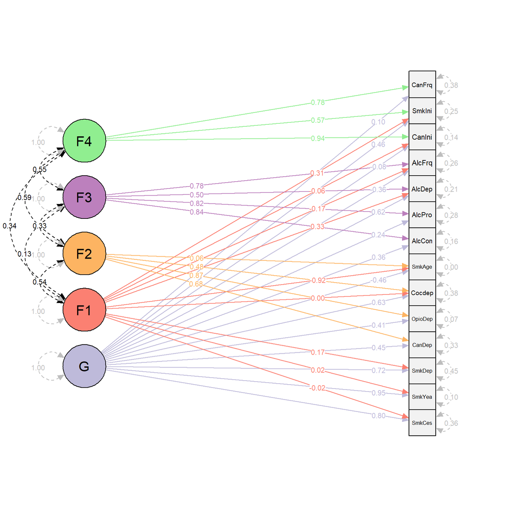

```r
semPaths(semPlotModel_GSEM(fit),
         layout="tree",
         curve = 2.5,
         whatLabels = "est",
         residuals = T,
         nodeLabels = nodelab,
         edge.color = edge.col,
         color = list(lat = c("#bebada", "#fb8072", "#fdb462", "#bc80bd", "lightgreen"),
              man = "#f2f2f2"),
         rotation = 2,
         edge.label.position = c(rep(0.9, 14), rep(0.7, 9), rep(0.3, 4), rep(0.3, 4), rep(0.7, 3), rep(0.5, 39)),
         )
```

### S-1 bifactor

Instead, we test an S-1 bifactor model. The fit is still very good, though it is unclear why cannabis initiation and alcohol frequency load negatively on G and the loading of cannabis frequency on G is not significant.

```r
bif <- 'G =~ NA*SMKCES + PACKYE + SMKDEP + CANDEP + COCDEP + OPIODEP + SMKAGE + ALCDEP + CANEV + CANFL + SMKINI + ALCCON + ALCFRQ + ALCP

F2 =~ NA*CANDEP + COCDEP + OPIODEP + SMKAGE
F3 =~ NA*ALCDEP + ALCCON + ALCFRQ + ALCP
F4 =~ NA*CANEV + CANFL + SMKINI

G~~1*G
F2~~1*F2
F3~~1*F3
F4~~1*F4

G ~~ 0*F2 + 0*F3 + 0*F4

a>.001
CANEV~~a*CANEV

b>.001
OPIODEP~~b*OPIODEP
'

#run the model
fit <- usermodel(ldscOut, estimation = "DWLS", model = bif, CFIcalc = TRUE)
```

```r
fitlabel <- paste0("CFI = ", round(fit$modelfit$CFI,3), ", SRMR = ", round(fit$modelfit$SRMR,3))
kable(fitlabel)
```

| x |
| --- |
| CFI = 0.953, SRMR = 0.065 |

**Click to expand table with model parameters**

```r
kable(fit$results)
```

|  | lhs | op | rhs | Unstand_Est | Unstand_SE | STD_Genotype | STD_Genotype_SE | STD_All | p_value |
| --- | --- | --- | --- | --- | --- | --- | --- | --- | --- |
| 41 | G | =~ | SMKCES | 0.1898576 | 0.00784001777346886 | 0.7065466 | 0.0291762831723307 | 0.7065466 | 0.0000000 |
| 39 | G | =~ | PACKYE | 0.2634023 | 0.0101385223676045 | 0.8729609 | 0.0336008263071646 | 0.8729609 | 0.0000000 |
| 42 | G | =~ | SMKDEP | 0.2698602 | 0.0176836064586659 | 0.7667749 | 0.0502458184125755 | 0.7667750 | 0.0000000 |
| 34 | G | =~ | CANDEP | 0.1459691 | 0.0235074238582215 | 0.4874722 | 0.078504199269148 | 0.4874703 | 0.0000000 |
| 37 | G | =~ | COCDEP | 0.3578941 | 0.0310094512893644 | 0.6560424 | 0.0568422273721075 | 0.6560424 | 0.0000000 |
| 38 | G | =~ | OPIODEP | 0.2120117 | 0.0383583221679846 | 0.4744508 | 0.0858399904124917 | 0.4744436 | 0.0000000 |
| 40 | G | =~ | SMKAGE | -0.1334341 | 0.00646200476505258 | -0.6101336 | 0.0295478141370009 | -0.6101336 | 0.0000000 |
| 31 | G | =~ | ALCDEP | 0.2878062 | 0.0192828398805868 | 0.7563964 | 0.0506781035085159 | 0.7563966 | 0.0000000 |
| 35 | G | =~ | CANEV | -0.0438739 | 0.0194989654283613 | -0.0764392 | 0.0339718940188925 | -0.0764392 | 0.0244450 |
| 36 | G | =~ | CANFL | 0.0225299 | 0.0157089702617285 | 0.1062873 | 0.0741089822167822 | 0.1062867 | 0.1515139 |
| 43 | G | =~ | SMKINI | 0.1883936 | 0.00746022213597848 | 0.5463092 | 0.0216333780526599 | 0.5463092 | 0.0000000 |
| 30 | G | =~ | ALCCON | 0.0945951 | 0.00812778912269869 | 0.3597289 | 0.0309085908375442 | 0.3597289 | 0.0000000 |
| 32 | G | =~ | ALCFRQ | -0.1181588 | 0.00808081444005036 | -0.4106661 | 0.0280852344362069 | -0.4106661 | 0.0000000 |
| 33 | G | =~ | ALCP | 0.0575725 | 0.00865337285266824 | 0.2393573 | 0.0359763695359596 | 0.2393573 | 0.0000000 |
| 12 | F2 | =~ | CANDEP | 0.1814703 | 0.0328376552656918 | 0.6060242 | 0.109662700063504 | 0.6060219 | 0.0000000 |
| 13 | F2 | =~ | COCDEP | 0.2073888 | 0.0431785209395895 | 0.3801536 | 0.079148607268224 | 0.3801536 | 0.0000016 |
| 14 | F2 | =~ | OPIODEP | 0.3431010 | 0.0505781290067764 | 0.7677967 | 0.113185553923953 | 0.7677851 | 0.0000000 |
| 15 | F2 | =~ | SMKAGE | -0.0876410 | 0.00988261596603086 | -0.4007397 | 0.0451888170529952 | -0.4007397 | 0.0000000 |
| 19 | F3 | =~ | ALCDEP | 0.2138130 | 0.0218139959340193 | 0.5619316 | 0.0573303458978008 | 0.5619317 | 0.0000000 |
| 18 | F3 | =~ | ALCCON | 0.2206043 | 0.00797342756560014 | 0.8389205 | 0.0303215756800026 | 0.8389205 | 0.0000000 |
| 20 | F3 | =~ | ALCFRQ | 0.2204853 | 0.00898034079979662 | 0.7663062 | 0.0312115627954526 | 0.7663062 | 0.0000000 |
| 21 | F3 | =~ | ALCP | 0.1971645 | 0.00886291524160049 | 0.8197106 | 0.0368475366426682 | 0.8197106 | 0.0000000 |
| 23 | F4 | =~ | CANEV | 0.5265137 | 0.0261429287241526 | 0.9173135 | 0.0455472733530385 | 0.9173134 | 0.0000000 |
| 24 | F4 | =~ | CANFL | 0.1642752 | 0.0192606718014058 | 0.7749878 | 0.0908645677055491 | 0.7749834 | 0.0000000 |
| 25 | F4 | =~ | SMKINI | 0.2288929 | 0.0101237204990796 | 0.6637505 | 0.0293570590356604 | 0.6637505 | 0.0000000 |
| 6 | CANEV | ~~ | CANEV | 0.0503040 | 0.0243311562467727 | 0.1526931 | 0.0738548568882207 | 0.1526931 | 0.0386896 |
| 44 | OPIODEP | ~~ | OPIODEP | 0.0370151 | 0.0721684438521245 | 0.1854150 | 0.361414998317531 | 0.1854094 | 0.6080221 |
| 49 | SMKINI | ~~ | SMKINI | 0.0310359 | 0.00378926312790832 | 0.2609815 | 0.0318639415361856 | 0.2609815 | 0.0000000 |
| 47 | SMKCES | ~~ | SMKCES | 0.0361602 | 0.00333311976941098 | 0.5007919 | 0.046161163142378 | 0.5007919 | 0.0000000 |
| 45 | PACKYE | ~~ | PACKYE | 0.0216628 | 0.0053817302577118 | 0.2379393 | 0.0591115745302198 | 0.2379393 | 0.0000569 |
| 46 | SMKAGE | ~~ | SMKAGE | 0.0223426 | 0.00236383627803429 | 0.4671447 | 0.0494234479070286 | 0.4671447 | 0.0000000 |
| 48 | SMKDEP | ~~ | SMKDEP | 0.0510386 | 0.0166077898931387 | 0.4120561 | 0.134081851825739 | 0.4120561 | 0.0021180 |
| 1 | ALCCON | ~~ | ALCCON | 0.0115346 | 0.00253351995428575 | 0.1668076 | 0.0366385071072479 | 0.1668076 | 0.0000053 |
| 3 | ALCFRQ | ~~ | ALCFRQ | 0.0202103 | 0.00333915959303806 | 0.2441281 | 0.0403350486494896 | 0.2441281 | 0.0000000 |
| 4 | ALCP | ~~ | ALCP | 0.0156660 | 0.00340144761914028 | 0.2707827 | 0.0587932618889416 | 0.2707826 | 0.0000041 |
| 2 | ALCDEP | ~~ | ALCDEP | 0.0162292 | 0.0259972212381322 | 0.1120970 | 0.17956659532258 | 0.1120970 | 0.5324520 |
| 5 | CANDEP | ~~ | CANDEP | 0.0354268 | 0.0292371540550479 | 0.3951133 | 0.326069868140484 | 0.3951102 | 0.2256260 |
| 7 | CANFL | ~~ | CANFL | 0.0174378 | 0.0155710486053276 | 0.3881082 | 0.346548573833386 | 0.3881039 | 0.2627612 |
| 8 | COCDEP | ~~ | COCDEP | 0.1265107 | 0.0511923434743049 | 0.4250917 | 0.172011971140523 | 0.4250917 | 0.0134630 |
| 10 | F2 | ~~ | F3 | 0.2179435 | 0.057587004930534 | 0.2179453 | 0.0575875440179715 | 0.2179453 | 0.0001540 |
| 11 | F2 | ~~ | F4 | 0.7465610 | 0.0654027487250216 | 0.7465687 | 0.0654041334711809 | 0.7465687 | 0.0000000 |
| 17 | F3 | ~~ | F4 | 0.5187755 | 0.0249050575719634 | 0.5187755 | 0.0249050572476286 | 0.5187755 | 0.0000000 |
| 29 | G | ~~ | G | 1.0000000 |  | 1.0000000 |  | 1.0000000 | NA |
| 9 | F2 | ~~ | F2 | 1.0000000 |  | 1.0000000 |  | 1.0000000 | NA |
| 16 | F3 | ~~ | F3 | 1.0000000 |  | 1.0000000 |  | 1.0000000 | NA |
| 22 | F4 | ~~ | F4 | 1.0000000 |  | 1.0000000 |  | 1.0000000 | NA |
| 26 | G | ~~ | F2 | 0.0000000 |  | 0.0000000 |  | 0.0000000 | NA |
| 27 | G | ~~ | F3 | 0.0000000 |  | 0.0000000 |  | 0.0000000 | NA |
| 28 | G | ~~ | F4 | 0.0000000 |  | 0.0000000 |  | 0.0000000 | NA |

#### Plot EFA-based bifactor S-1 model

```r
nodelab <- c("SmkCes", "SmkYea", "SmkDep",
             "CanDep","Cocdep","OpioDep", "SmkAge","AlcDep","AlcCon","AlcFrq", "AlcPro",
             "CanIni", "CanFrq","SmkIni",
             "G", "F2", "F3", "F4")

edge.col <- c(rep("#bebada",14),
              rep("#fb8072",4),
              rep("#fdb462",4),
              rep("#bc80bd",3),
              rep("grey",14),
              rep("black",3),
              rep("grey", 4),
              rep(alpha("white", 0), 3))


svg("results/semplot_4F_S-1.svg", width = 8, height = 8)

semPaths(semPlotModel_GSEM(fit),
         layout="tree",
         curve = 2.5,
         whatLabels = "est",
         residuals = T,
         nodeLabels = nodelab,
         edge.color = edge.col,
         color = list(lat = c("#bebada", "#fb8072", "#fdb462", "#bc80bd"),
              man = "#f2f2f2"),
         rotation = 2,
         edge.label.position = c(rep(0.8, 14), rep(0.6, 4), rep(0.4, 4), rep(0.6, 3), rep(0.5, 30)),
         )

dev.off()
```

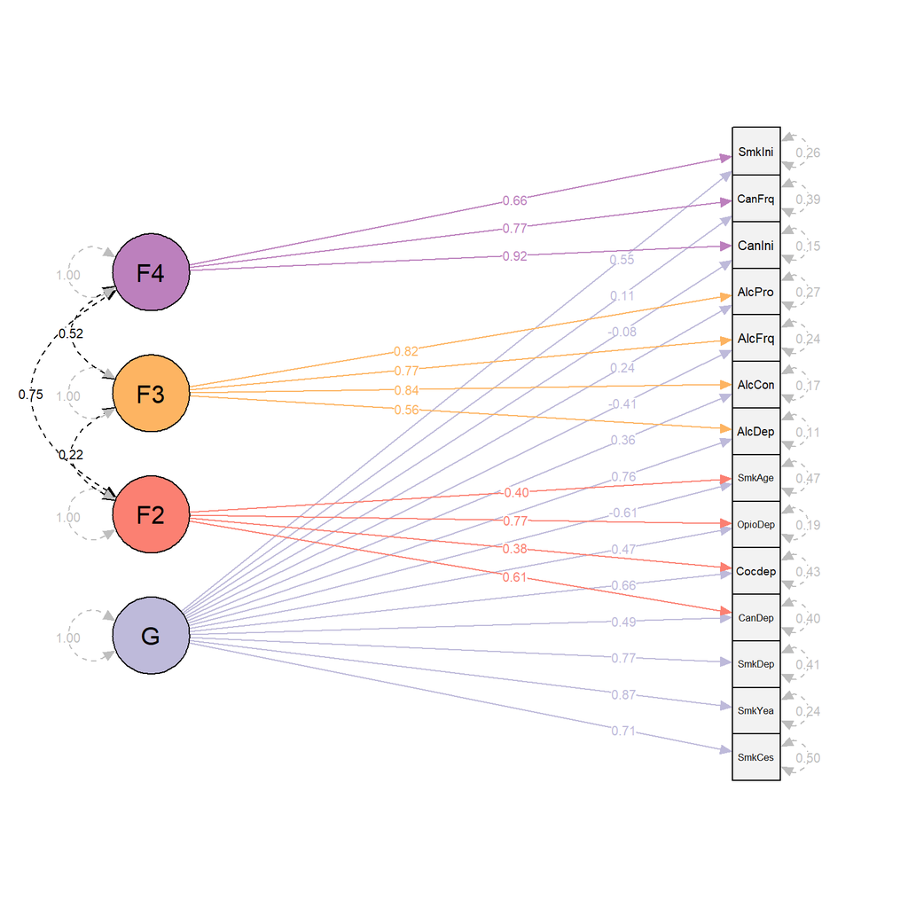

```r
semPaths(semPlotModel_GSEM(fit),
         layout="tree",
         curve = 2.5,
         whatLabels = "est",
         residuals = T,
         nodeLabels = nodelab,
         edge.color = edge.col,
         color = list(lat = c("#bebada", "#fb8072", "#fdb462", "#bc80bd"),
              man = "#f2f2f2"),
         rotation = 2,
         edge.label.position = c(rep(0.8, 14), rep(0.6, 4), rep(0.4, 4), rep(0.6, 3), rep(0.5, 30)),
         )
```

### Second-order factor

This next bifactor model is hierarchical, such that the general factor G is made up by the other specific factors. The correlation between the factors is forced through G, so they are orthogonal. It shows good fit, but the loading of cannabis initiation on F1 is negative, and F4 does not load significantly on G.

```r
bif <- 'G =~ NA*F1 + F2 + F3 + F4

F1 =~ NA*SMKCES + PACKYE + SMKDEP + ALCDEP + ALCFRQ + COCDEP + CANEV + SMKINI + SMKAGE
F2 =~ NA*CANDEP + COCDEP + OPIODEP + SMKAGE
F3 =~ NA*ALCDEP + ALCCON + ALCFRQ + ALCP
F4 =~ NA*CANEV + CANFL + SMKINI

G~~1*G
F1~~1*F1
F2~~1*F2
F3~~1*F3
F4~~1*F4

G ~~ 0*F1 + 0*F2 + 0*F3 + 0*F4
F1 ~~ 0*F2 + 0*F3 + 0*F4
F2 ~~ 0*F3 + 0*F4
F3 ~~ 0*F4

'

#run the model
fit <- usermodel(ldscOut, estimation = "DWLS", model = bif, CFIcalc = TRUE)
```

```r
fitlabel <- paste0("CFI = ", round(fit$modelfit$CFI,3), ", SRMR = ", round(fit$modelfit$SRMR,3))
kable(fitlabel)
```

| x |
| --- |
| CFI = 0.941, SRMR = 0.085 |

**Click to expand table with model parameters**

```r
kable(fit$results)
```

|  | lhs | op | rhs | Unstand_Est | Unstand_SE | STD_Genotype | STD_Genotype_SE | STD_All | p_value |
| --- | --- | --- | --- | --- | --- | --- | --- | --- | --- |
| 44 | G | =~ | F1 | 0.6758293 | 0.0871973758093 | 0.6758294 | 0.0871979015791142 | 0.6758294 | 0.0000000 |
| 45 | G | =~ | F2 | 1.0574965 | 0.163515234860455 | 1.0574961 | 0.163516140792944 | 1.0574961 | 0.0000000 |
| 46 | G | =~ | F3 | 0.7249061 | 0.064596681544295 | 0.7249067 | 0.06459825361952 | 0.7249067 | 0.0000000 |
| 47 | G | =~ | F4 | 348.9833101 | 1846350.69343813 | 329.0177890 | 1547301.98753872 | 329.0177890 | 0.9998492 |
| 19 | F1 | =~ | SMKCES | 0.1563863 | 0.00882378695877419 | 0.5819849 | 0.032837335117587 | 0.5819849 | 0.0000000 |
| 17 | F1 | =~ | PACKYE | 0.2169397 | 0.0122264104141079 | 0.7189759 | 0.0405204047068398 | 0.7189759 | 0.0000000 |
| 20 | F1 | =~ | SMKDEP | 0.2230819 | 0.0166009299609486 | 0.6338601 | 0.0471694359621386 | 0.6338601 | 0.0000000 |
| 13 | F1 | =~ | ALCDEP | 0.1720746 | 0.0192941964330954 | 0.4522369 | 0.0507069183769355 | 0.4522369 | 0.0000000 |
| 14 | F1 | =~ | ALCFRQ | -0.1654242 | 0.00839064822958159 | -0.5749393 | 0.029162195723009 | -0.5749393 | 0.0000000 |
| 16 | F1 | =~ | COCDEP | 0.2120896 | 0.0339886326715221 | 0.3887733 | 0.0623033042454373 | 0.3887733 | 0.0000000 |
| 15 | F1 | =~ | CANEV | -0.3235861 | 0.0422974672889108 | -0.5637650 | 0.0736935677793057 | -0.5637650 | 0.0000000 |
| 21 | F1 | =~ | SMKINI | 0.0273526 | 0.0227219527605753 | 0.0793185 | 0.0658907444052327 | 0.0793185 | 0.2286687 |
| 18 | F1 | =~ | SMKAGE | -0.0820220 | 0.00913337395208175 | -0.3750497 | 0.041762759232844 | -0.3750497 | 0.0000000 |
| 25 | F2 | =~ | CANDEP | 0.1803892 | 0.0251469656951725 | 0.6024190 | 0.0839796212181359 | 0.6024190 | 0.0000000 |
| 26 | F2 | =~ | COCDEP | 0.1671755 | 0.037744871469797 | 0.3064430 | 0.0691887730734698 | 0.3064430 | 0.0000095 |
| 27 | F2 | =~ | OPIODEP | 0.2996698 | 0.0498725498930024 | 0.6706149 | 0.111607206910599 | 0.6706149 | 0.0000000 |
| 28 | F2 | =~ | SMKAGE | -0.0609585 | 0.00945171478293468 | -0.2787354 | 0.043218472364435 | -0.2787354 | 0.0000000 |
| 32 | F3 | =~ | ALCDEP | 0.1866220 | 0.0186436908207751 | 0.4904694 | 0.0489983756296233 | 0.4904694 | 0.0000000 |
| 31 | F3 | =~ | ALCCON | 0.1974798 | 0.00950427665935265 | 0.7509815 | 0.0361434359475766 | 0.7509815 | 0.0000000 |
| 33 | F3 | =~ | ALCFRQ | 0.1886281 | 0.0101957192679552 | 0.6555854 | 0.0354358237807346 | 0.6555854 | 0.0000000 |
| 34 | F3 | =~ | ALCP | 0.1596432 | 0.0084753183354227 | 0.6637159 | 0.035236305791253 | 0.6637159 | 0.0000000 |
| 36 | F4 | =~ | CANEV | 0.0018114 | 9.5832301683485 | 0.0033474 | 15.7416625693564 | 0.0033474 | 0.9998492 |
| 37 | F4 | =~ | CANFL | 0.0003827 | 2.02481325943799 | 0.0019151 | 9.0061481775494 | 0.0019151 | 0.9998492 |
| 38 | F4 | =~ | SMKINI | 0.0008117 | 4.29456966920625 | 0.0024967 | 11.7414601245336 | 0.0024967 | 0.9998492 |
| 53 | SMKINI | ~~ | SMKINI | 0.0271063 | 0.00396106684142532 | 0.2279378 | 0.033308724358027 | 0.2279378 | 0.0000000 |
| 51 | SMKCES | ~~ | SMKCES | 0.0365790 | 0.00330866221888135 | 0.5065909 | 0.0458224417687366 | 0.5065909 | 0.0000000 |
| 49 | PACKYE | ~~ | PACKYE | 0.0224850 | 0.00537381930028813 | 0.2469697 | 0.0590246716425312 | 0.2469697 | 0.0000286 |
| 50 | SMKAGE | ~~ | SMKAGE | 0.0230095 | 0.00223886541658314 | 0.4810866 | 0.0468105702590317 | 0.4810866 | 0.0000000 |
| 52 | SMKDEP | ~~ | SMKDEP | 0.0513674 | 0.0166309199430065 | 0.4147109 | 0.134268593227077 | 0.4147109 | 0.0020106 |
| 1 | ALCCON | ~~ | ALCCON | 0.0096577 | 0.00276796250227635 | 0.1396649 | 0.0400289027020013 | 0.1396649 | 0.0004847 |
| 3 | ALCFRQ | ~~ | ALCFRQ | 0.0192178 | 0.00334615228509369 | 0.2321397 | 0.0404195561701318 | 0.2321397 | 0.0000000 |
| 4 | ALCP | ~~ | ALCP | 0.0189758 | 0.00350970878772015 | 0.3279930 | 0.0606645123289279 | 0.3279930 | 0.0000001 |
| 2 | ALCDEP | ~~ | ALCDEP | 0.0170495 | 0.0259249959422507 | 0.1177634 | 0.179067711752793 | 0.1177634 | 0.5107654 |
| 6 | CANEV | ~~ | CANEV | 0.0537915 | 0.0243274804244529 | 0.1632775 | 0.073843780135464 | 0.1632775 | 0.0270260 |
| 5 | CANDEP | ~~ | CANDEP | 0.0207353 | 0.0294586056546642 | 0.2312525 | 0.328539984853642 | 0.2312525 | 0.4815090 |
| 7 | CANFL | ~~ | CANFL | 0.0270929 | 0.0155134970112398 | 0.6029786 | 0.345267698805672 | 0.6029786 | 0.0807399 |
| 8 | COCDEP | ~~ | COCDEP | 0.1222001 | 0.0515131114054875 | 0.4106063 | 0.173089921735103 | 0.4106063 | 0.0176819 |
| 48 | OPIODEP | ~~ | OPIODEP | 0.0094551 | 0.0754484319838743 | 0.0473467 | 0.377842051583042 | 0.0473467 | 0.9002716 |
| 43 | G | ~~ | G | 1.0000000 |  | 1.0000000 |  | 1.0000000 | NA |
| 9 | F1 | ~~ | F1 | 1.0000000 |  | 1.0000000 |  | 1.0000000 | NA |
| 22 | F2 | ~~ | F2 | 1.0000000 |  | 1.0000000 |  | 1.0000000 | NA |
| 29 | F3 | ~~ | F3 | 1.0000000 |  | 1.0000000 |  | 1.0000000 | NA |
| 35 | F4 | ~~ | F4 | 1.0000000 |  | 1.0000000 |  | 1.0000000 | NA |
| 39 | G | ~~ | F1 | 0.0000000 |  | 0.0000000 |  | 0.0000000 | NA |
| 40 | G | ~~ | F2 | 0.0000000 |  | 0.0000000 |  | 0.0000000 | NA |
| 41 | G | ~~ | F3 | 0.0000000 |  | 0.0000000 |  | 0.0000000 | NA |
| 42 | G | ~~ | F4 | 0.0000000 |  | 0.0000000 |  | 0.0000000 | NA |
| 10 | F1 | ~~ | F2 | 0.0000000 |  | 0.0000000 |  | 0.0000000 | NA |
| 11 | F1 | ~~ | F3 | 0.0000000 |  | 0.0000000 |  | 0.0000000 | NA |
| 12 | F1 | ~~ | F4 | 0.0000000 |  | 0.0000000 |  | 0.0000000 | NA |
| 23 | F2 | ~~ | F3 | 0.0000000 |  | 0.0000000 |  | 0.0000000 | NA |
| 24 | F2 | ~~ | F4 | 0.0000000 |  | 0.0000000 |  | 0.0000000 | NA |
| 30 | F3 | ~~ | F4 | 0.0000000 |  | 0.0000000 |  | 0.0000000 | NA |

#### Plot EFA-based second-order factor model

```r
nodelab <- c("SmkCes", "SmkYea", "SmkDep",
             "Cocdep", "SmkAge","AlcDep", "AlcFrq", "CanDep","OpioDep",
             "CanIni", "SmkIni",
             "AlcCon",  "AlcPro", "CanFrq",
             "G", "F1", "F2", "F3", "F4")

edge.col <- c(rep("#bebada",4),
              rep("#fb8072",9),
              rep("#fdb462",4),
              rep("#bc80bd",4),
              rep("lightgreen", 3),
              rep("grey", 19),
              rep("white", 10))


svg("results/semplot_4F_second-order.svg", width = 10, height = 8)

semPaths(semPlotModel_GSEM(fit),
         layout="tree",
         curve = 0,
         whatLabels = "est",
         residuals = T,
         nodeLabels = nodelab,
         edge.color = edge.col,
         color = list(lat = c("#bebada", "#fb8072", "#fdb462", "#bc80bd", "lightgreen"),
              man = "#f2f2f2"),
         rotation = 2,
         edge.label.position = c(rep(0.5, 4), rep(0.8, 9), rep(0.4, 4), rep(0.2, 4), rep(0.4, 3), rep(0.5, 39))
         )

dev.off()
```

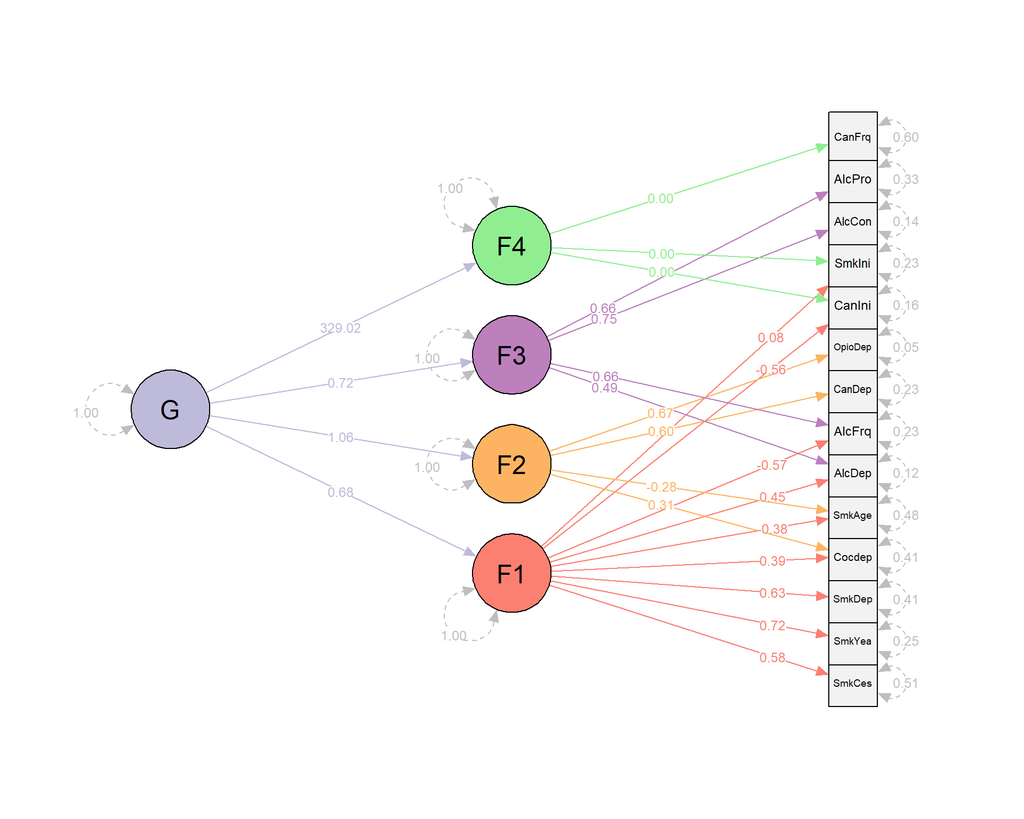

```r
semPaths(semPlotModel_GSEM(fit),
         layout="tree",
         curve = 0,
         whatLabels = "est",
         residuals = T,
         nodeLabels = nodelab,
         edge.color = edge.col,
         color = list(lat = c("#bebada", "#fb8072", "#fdb462", "#bc80bd", "lightgreen"),
              man = "#f2f2f2"),
         rotation = 2,
         edge.label.position = c(rep(0.5, 4), rep(0.8, 9), rep(0.4, 4), rep(0.2, 4), rep(0.4, 3), rep(0.5, 39))
         )
```

## Theoretical models

We now move on to models that are not based on the original EFA but rather on what seems sensible at the face of it. We grouped by substance type as well as by trait type.

### Correlated factors by substance

```r
cfa <- '
SMK =~ NA*PACKYE + SMKCES + SMKDEP + SMKAGE + SMKINI
ALC =~ NA*ALCCON + ALCFRQ + ALCP + ALCDEP
CAN =~ NA*CANEV + CANFL + CANDEP

SMK~~1*SMK
ALC~~1*ALC
CAN~~1*CAN

a>.001
ALCDEP~~a*ALCDEP
'

#run the model
fit <- usermodel(ldscOut, estimation = "DWLS", model = cfa, CFIcalc = TRUE)
```

```r
fitlabel <- paste0("CFI = ", round(fit$modelfit$CFI,3), ", SRMR = ", round(fit$modelfit$SRMR,3))
kable(fitlabel)
```

| x |
| --- |
| CFI = 0.613, SRMR = 0.18 |

**Click to expand table with model parameters**

```r
kable(fit$results)
```

|  | lhs | op | rhs | Unstand_Est | Unstand_SE | STD_Genotype | STD_Genotype_SE | STD_All | p_value |
| --- | --- | --- | --- | --- | --- | --- | --- | --- | --- |
| 22 | SMK | =~ | PACKYE | 0.1721992 | 0.00980471085276502 | 0.5707172 | 0.0324945781129711 | 0.5707171 | 0.0000000 |
| 24 | SMK | =~ | SMKCES | 0.1316621 | 0.00779315922121384 | 0.4901750 | 0.0290130366079927 | 0.4901750 | 0.0000000 |
| 25 | SMK | =~ | SMKDEP | 0.2060877 | 0.0163417132869873 | 0.5856769 | 0.0464402297840081 | 0.5856764 | 0.0000000 |
| 23 | SMK | =~ | SMKAGE | -0.1438257 | 0.00603030628005234 | -0.6775600 | 0.0284084028349891 | -0.6775599 | 0.0000000 |
| 26 | SMK | =~ | SMKINI | 0.3290490 | 0.0105642422201396 | 0.9548732 | 0.0306553109212399 | 0.9548734 | 0.0000000 |
| 3 | ALC | =~ | ALCCON | 0.2508893 | 0.00867588542961259 | 0.9547386 | 0.0330158151104389 | 0.9547394 | 0.0000000 |
| 5 | ALC | =~ | ALCFRQ | 0.0673005 | 0.00702117528495845 | 0.2344133 | 0.0244628262905781 | 0.2344133 | 0.0000000 |
| 6 | ALC | =~ | ALCP | 0.2003832 | 0.00922919625902615 | 0.8407500 | 0.0387261884666623 | 0.8407507 | 0.0000000 |
| 4 | ALC | =~ | ALCDEP | 0.3824858 | 0.0223647162564604 | 1.0251609 | 0.0599061185510006 | 1.0251609 | 0.0000000 |
| 13 | CAN | =~ | CANEV | 0.4152259 | 0.0337673177653976 | 0.7241420 | 0.0588899483880863 | 0.7241421 | 0.0000000 |
| 14 | CAN | =~ | CANFL | 0.1861263 | 0.021656968778005 | 0.9063463 | 0.105460322058163 | 0.9063481 | 0.0000000 |
| 12 | CAN | =~ | CANDEP | 0.2529650 | 0.0306690875006888 | 0.8680770 | 0.105242594630192 | 0.8680596 | 0.0000000 |
| 8 | ALCDEP | ~~ | ALCDEP | 0.0010001 | 0.0277897988537441 | 0.0009999 | 0.199412289964693 | 0.0009999 | 0.9712910 |
| 30 | SMKINI | ~~ | SMKINI | 0.0104685 | 0.00569100455099185 | 0.0882167 | 0.047921564045941 | 0.0882168 | 0.0658445 |
| 28 | SMKCES | ~~ | SMKCES | 0.0548165 | 0.0032449294731532 | 0.7597285 | 0.0449741338415437 | 0.7597285 | 0.0000000 |
| 18 | PACKYE | ~~ | PACKYE | 0.0613900 | 0.0053772674468964 | 0.6742821 | 0.0590629178743661 | 0.6742820 | 0.0000000 |
| 27 | SMKAGE | ~~ | SMKAGE | 0.0243743 | 0.0021329201338426 | 0.5409126 | 0.0473343331465282 | 0.5409125 | 0.0000000 |
| 29 | SMKDEP | ~~ | SMKDEP | 0.0813526 | 0.0173121729858035 | 0.6569843 | 0.13981161581369 | 0.6569832 | 0.0000026 |
| 7 | ALCCON | ~~ | ALCCON | 0.0060852 | 0.00339650919371835 | 0.0884725 | 0.0491896854494354 | 0.0884726 | 0.0731978 |
| 9 | ALCFRQ | ~~ | ALCFRQ | 0.0778469 | 0.00327752672524183 | 0.9450503 | 0.0397887641648743 | 0.9450504 | 0.0000000 |
| 10 | ALCP | ~~ | ALCP | 0.0166405 | 0.00387312151347326 | 0.2931378 | 0.0681952701325877 | 0.2931383 | 0.0000174 |
| 16 | CANEV | ~~ | CANEV | 0.1563612 | 0.0265164227933982 | 0.4756180 | 0.0806493504671056 | 0.4756182 | 0.0000000 |
| 15 | CANDEP | ~~ | CANDEP | 0.0209324 | 0.0295747788181949 | 0.2464824 | 0.348254354968613 | 0.2464725 | 0.4790820 |
| 17 | CANFL | ~~ | CANFL | 0.0075290 | 0.0160922469640556 | 0.1785324 | 0.381587230199771 | 0.1785331 | 0.6398794 |
| 19 | SMK | ~~ | ALC | 0.4837942 | 0.0241211619247553 | 0.4838559 | 0.0241195706920385 | 0.4838559 | 0.0000000 |
| 20 | SMK | ~~ | CAN | 0.5136622 | 0.045569360812928 | 0.5136675 | 0.0455701504511341 | 0.5136675 | 0.0000000 |
| 2 | ALC | ~~ | CAN | 0.5693026 | 0.0484050436534426 | 0.5693196 | 0.0484060682390106 | 0.5693196 | 0.0000000 |
| 21 | SMK | ~~ | SMK | 1.0000000 |  | 1.0000000 |  | 1.0000000 | NA |
| 1 | ALC | ~~ | ALC | 1.0000000 |  | 1.0000000 |  | 1.0000000 | NA |
| 11 | CAN | ~~ | CAN | 1.0000000 |  | 1.0000000 |  | 1.0000000 | NA |

### Bifactor by substance

```r
bif <- 'G =~ NA*PACKYE + SMKCES + SMKDEP + SMKAGE + SMKINI + ALCCON + ALCFRQ + ALCP + ALCDEP + CANEV + CANFL + CANDEP

SMK =~ NA*PACKYE + SMKCES + SMKDEP + SMKAGE + SMKINI
ALC =~ NA*ALCCON + ALCFRQ + ALCP + ALCDEP
CAN =~ NA*CANEV + CANFL + CANDEP

G ~~ 0*SMK + 0*ALC + 0*CAN

G~~1*G
SMK~~1*SMK
ALC~~1*ALC
CAN~~1*CAN

b>.001
CANEV~~b*CANEV

c>.001
SMKINI~~c*SMKINI
'

#run the model
fit <- usermodel(ldscOut, estimation = "DWLS", model = bif, CFIcalc = TRUE)
```

```r
fitlabel <- paste0("CFI = ", round(fit$modelfit$CFI,3), ", SRMR = ", round(fit$modelfit$SRMR,3))
kable(fitlabel)
```

| x |
| --- |
| CFI = 0.968, SRMR = 0.054 |

**Click to expand table with model parameters**

```r
kable(fit$results)
```

|  | lhs | op | rhs | Unstand_Est | Unstand_SE | STD_Genotype | STD_Genotype_SE | STD_All | p_value |
| --- | --- | --- | --- | --- | --- | --- | --- | --- | --- |
| 29 | G | =~ | PACKYE | 0.2768854 | 0.0107692079790868 | 0.9180005 | 0.0357113538949053 | 0.9180006 | 0.0000000 |
| 31 | G | =~ | SMKCES | 0.1921364 | 0.00733243374826127 | 0.7154117 | 0.0273174288470268 | 0.7154117 | 0.0000000 |
| 32 | G | =~ | SMKDEP | 0.2613045 | 0.018683323934528 | 0.7426287 | 0.0531170766715557 | 0.7426288 | 0.0000000 |
| 30 | G | =~ | SMKAGE | -0.1346518 | 0.00688864201712666 | -0.6337507 | 0.0324397181336771 | -0.6337507 | 0.0000000 |
| 33 | G | =~ | SMKINI | 0.2026416 | 0.0121458348800981 | 0.5879107 | 0.0352037971771695 | 0.5794688 | 0.0000000 |
| 22 | G | =~ | ALCCON | 0.0957425 | 0.00847036655092994 | 0.3642058 | 0.0321712638704834 | 0.3642058 | 0.0000000 |
| 24 | G | =~ | ALCFRQ | -0.1113089 | 0.0100577001030065 | -0.3879898 | 0.0349606406567015 | -0.3879897 | 0.0000000 |
| 25 | G | =~ | ALCP | 0.0609128 | 0.00910638569800639 | 0.2554056 | 0.0381451682484098 | 0.2554056 | 0.0000000 |
| 23 | G | =~ | ALCDEP | 0.2876120 | 0.0187709524729959 | 0.7701740 | 0.0502796627725513 | 0.7701746 | 0.0000000 |
| 27 | G | =~ | CANEV | -0.0042220 | 0.0253101819761453 | -0.0077671 | 0.0439519655769809 | -0.0077007 | 0.8675202 |
| 28 | G | =~ | CANFL | 0.0404422 | 0.0167831415589199 | 0.1967733 | 0.0816404544049093 | 0.1967708 | 0.0159660 |
| 26 | G | =~ | CANDEP | 0.1655769 | 0.0231146468457219 | 0.5681165 | 0.0792834677969662 | 0.5681118 | 0.0000000 |
| 38 | SMK | =~ | PACKYE | 0.0385134 | 0.0160314967488922 | -0.1272898 | 0.0528959403332351 | -0.1272898 | 0.0162898 |
| 40 | SMK | =~ | SMKCES | 0.0146660 | 0.0114380941595328 | -0.0542462 | 0.0424013806002348 | -0.0542462 | 0.1997696 |
| 41 | SMK | =~ | SMKDEP | -0.0012658 | 0.0214850696515358 | 0.0036353 | 0.0608527730834684 | 0.0036353 | 0.9530202 |
| 39 | SMK | =~ | SMKAGE | 0.0580524 | 0.00730793482304522 | -0.2743521 | 0.0343010390695782 | -0.2743521 | 0.0000000 |
| 42 | SMK | =~ | SMKINI | -0.2832556 | 0.0227261231201569 | 0.8262628 | 0.0661543057817945 | 0.8143983 | 0.0000000 |
| 3 | ALC | =~ | ALCCON | 0.2152921 | 0.00949654352246082 | 0.8195810 | 0.0360777280754691 | 0.8195811 | 0.0000000 |
| 5 | ALC | =~ | ALCFRQ | 0.2266879 | 0.00958310612964293 | 0.7895785 | 0.0333313692987516 | 0.7895785 | 0.0000000 |
| 6 | ALC | =~ | ALCP | 0.1930502 | 0.00921477179570245 | 0.8102109 | 0.0386453753688978 | 0.8102110 | 0.0000000 |
| 4 | ALC | =~ | ALCDEP | 0.2090140 | 0.0234664627588824 | 0.5600953 | 0.0627832242739593 | 0.5600957 | 0.0000000 |
| 13 | CAN | =~ | CANEV | 0.5775290 | 0.0445726552782388 | 1.0080972 | 0.0777757839058983 | 0.9994787 | 0.0000000 |
| 14 | CAN | =~ | CANFL | 0.1716128 | 0.018918785535931 | 0.8357791 | 0.0921352307014312 | 0.8357686 | 0.0000000 |
| 12 | CAN | =~ | CANDEP | 0.1165019 | 0.0263146325823043 | 0.4000059 | 0.0902669397909022 | 0.4000026 | 0.0000095 |
| 16 | CANEV | ~~ | CANEV | 0.0010000 | 0.0482398161951583 | 0.0010000 | 0.14695262414436 | 0.0010000 | 0.9834612 |
| 46 | SMKINI | ~~ | SMKINI | 0.0009991 | 0.0115280578043982 | 0.0009998 | 0.0980808302465994 | 0.0009998 | 0.9309338 |
| 44 | SMKCES | ~~ | SMKCES | 0.0350199 | 0.0034186495565257 | 0.4852435 | 0.047398146831104 | 0.4852435 | 0.0000000 |
| 34 | PACKYE | ~~ | PACKYE | 0.0128937 | 0.00628976747731912 | 0.1410722 | 0.0691228483748109 | 0.1410722 | 0.0403687 |
| 43 | SMKAGE | ~~ | SMKAGE | 0.0235590 | 0.00209433969436909 | 0.5230910 | 0.0464958380671633 | 0.5230910 | 0.0000000 |
| 45 | SMKDEP | ~~ | SMKDEP | 0.0555432 | 0.0168585730508253 | 0.4484891 | 0.136158075885664 | 0.4484892 | 0.0009854 |
| 7 | ALCCON | ~~ | ALCCON | 0.0135133 | 0.00277067479910796 | 0.1956410 | 0.0401117555587514 | 0.1956411 | 0.0000011 |
| 9 | ALCFRQ | ~~ | ALCFRQ | 0.0185991 | 0.00329922852228549 | 0.2260299 | 0.0400183958989346 | 0.2260298 | 0.0000000 |
| 10 | ALCP | ~~ | ALCP | 0.0158152 | 0.00342160754930953 | 0.2783261 | 0.0602476280048919 | 0.2783261 | 0.0000038 |
| 8 | ALCDEP | ~~ | ALCDEP | 0.0129829 | 0.0265252200560425 | 0.0931237 | 0.190292691522573 | 0.0931239 | 0.6245184 |
| 15 | CANDEP | ~~ | CANDEP | 0.0439352 | 0.0284250634937809 | 0.5172555 | 0.33472009738957 | 0.5172469 | 0.1221890 |
| 17 | CANFL | ~~ | CANFL | 0.0110855 | 0.0155927660351267 | 0.2627788 | 0.369742855665774 | 0.2627722 | 0.4771213 |
| 35 | SMK | ~~ | ALC | -0.3810844 | 0.0395538590045242 | 0.3794319 | 0.0393968554592594 | 0.3794319 | 0.0000000 |
| 36 | SMK | ~~ | CAN | -0.6680032 | 0.0640419589877565 | 0.6644869 | 0.0637204850509296 | 0.6644869 | 0.0000000 |
| 2 | ALC | ~~ | CAN | 0.4733169 | 0.0431660762792386 | 0.4729982 | 0.0431432320995621 | 0.4729982 | 0.0000000 |
| 21 | G | ~~ | SMK | 0.0000000 |  | 0.0000000 |  | 0.0000000 | NA |
| 18 | G | ~~ | ALC | 0.0000000 |  | 0.0000000 |  | 0.0000000 | NA |
| 19 | G | ~~ | CAN | 0.0000000 |  | 0.0000000 |  | 0.0000000 | NA |
| 20 | G | ~~ | G | 1.0000000 |  | 1.0000000 |  | 1.0000000 | NA |
| 37 | SMK | ~~ | SMK | 1.0000000 |  | 1.0000000 |  | 1.0000000 | NA |
| 1 | ALC | ~~ | ALC | 1.0000000 |  | 1.0000000 |  | 1.0000000 | NA |
| 11 | CAN | ~~ | CAN | 1.0000000 |  | 1.0000000 |  | 1.0000000 | NA |

#### Plot per substance bifactor model

```r
nodelab <- c("SmkYea", "SmkCes", "SmkDep", "SmkAge", "SmkIni",
             "AlcCon", "AlcFrq", "AlcPro", "AlcDep",
             "CanIni", "CanFrq", "CanDep",
             "G", "SMK", "ALC", "CAN")

edge.col <- c(rep("#bebada",12),
              rep("#fb8072",5),
              rep("#fdb462",4),
              rep("#bc80bd",3),
              rep("grey", 12),
              rep("black", 3),
              rep("white", 3),
              rep("grey", 4))


svg("results/semplot_per-sub_bifactor.svg", width = 10, height = 8)

semPaths(semPlotModel_GSEM(fit),
         layout="tree",
         curve = 2.5,
         whatLabels = "est",
         residuals = T,
         nodeLabels = nodelab,
         edge.color = edge.col,
         color = list(lat = c("#bebada", "#fb8072", "#fdb462", "#bc80bd"),
              man = "#f2f2f2"),
         rotation = 2,
         edge.label.position = c(rep(0.8, 12), rep(0.2, 5), rep(0.4, 4), rep(0.6, 3), rep(0.5, 28))
         )

dev.off()
```

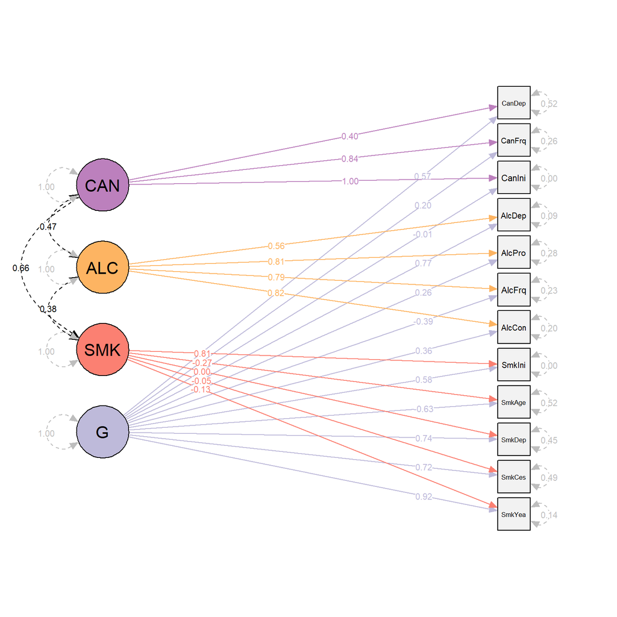

```r
semPaths(semPlotModel_GSEM(fit),
         layout="tree",
         curve = 2.5,
         whatLabels = "est",
         residuals = T,
         nodeLabels = nodelab,
         edge.color = edge.col,
         color = list(lat = c("#bebada", "#fb8072", "#fdb462", "#bc80bd"),
              man = "#f2f2f2"),
         rotation = 2,
         edge.label.position = c(rep(0.8, 12), rep(0.2, 5), rep(0.4, 4), rep(0.6, 3), rep(0.5, 28))
         )
```

### S-1 by substance

Instead, we fit the model without the first factor (SMK), because it is already captured by G. This model is not very intuitive, because the first factor was not more ‘general’ than the others. The fit is poor.

```r
bif <- 'G =~ NA*PACKYE + SMKCES + SMKDEP + SMKAGE + SMKINI + ALCCON + ALCFRQ + ALCP + ALCDEP + CANEV + CANFL + CANDEP + COCDEP + OPIODEP

ALC =~ NA*ALCCON + ALCFRQ + ALCP + ALCDEP
CAN =~ NA*CANEV + CANFL + CANDEP

G~~1*G
ALC~~1*ALC
CAN~~1*CAN

G ~~ 0*ALC + 0*CAN

a > .001
CANEV ~~ a*CANEV

'

#run the model
fit <- usermodel(ldscOut, estimation = "DWLS", model = bif, CFIcalc = TRUE)
```

```r
fitlabel <- paste0("CFI = ", round(fit$modelfit$CFI,3), ", SRMR = ", round(fit$modelfit$SRMR,3))
kable(fitlabel)
```

| x |
| --- |
| CFI = 0.776, SRMR = 0.113 |

**Click to expand table with model parameters**

```r
kable(fit$results)
```

|  | lhs | op | rhs | Unstand_Est | Unstand_SE | STD_Genotype | STD_Genotype_SE | STD_All | p_value |
| --- | --- | --- | --- | --- | --- | --- | --- | --- | --- |
| 31 | G | =~ | PACKYE | 0.2073269 | 0.00957168731144717 | 0.6871176 | 0.0317222379566119 | 0.6871176 | 0.0000000 |
| 33 | G | =~ | SMKCES | 0.1540602 | 0.00776712951551996 | 0.5733291 | 0.0289050527633436 | 0.5733291 | 0.0000000 |
| 34 | G | =~ | SMKDEP | 0.2332621 | 0.0163462079859674 | 0.6627859 | 0.0464457379993463 | 0.6627859 | 0.0000000 |
| 32 | G | =~ | SMKAGE | -0.1533527 | 0.00621575943380066 | -0.7012116 | 0.0284218125267743 | -0.7012115 | 0.0000000 |
| 35 | G | =~ | SMKINI | 0.2677605 | 0.00792779585650344 | 0.7764592 | 0.0229891912243921 | 0.7764592 | 0.0000000 |
| 22 | G | =~ | ALCCON | 0.1341340 | 0.006453556595518 | 0.5100922 | 0.0245418637527048 | 0.5100922 | 0.0000000 |
| 24 | G | =~ | ALCFRQ | -0.0497825 | 0.00591286490238579 | -0.1730181 | 0.0205504510155588 | -0.1730181 | 0.0000000 |
| 25 | G | =~ | ALCP | 0.0961476 | 0.00759295170604795 | 0.3997373 | 0.0315676631804484 | 0.3997373 | 0.0000000 |
| 23 | G | =~ | ALCDEP | 0.3207527 | 0.0171522232765993 | 0.8429869 | 0.04507859623659 | 0.8429867 | 0.0000000 |
| 27 | G | =~ | CANEV | 0.1619130 | 0.0175902976595045 | 0.2820807 | 0.0306469074122021 | 0.2797911 | 0.0000000 |
| 28 | G | =~ | CANFL | 0.0861944 | 0.0157269987270558 | 0.4066500 | 0.074193761418869 | 0.4066748 | 0.0000000 |
| 26 | G | =~ | CANDEP | 0.2025966 | 0.0207767717544924 | 0.6765832 | 0.0693863124757876 | 0.6765841 | 0.0000000 |
| 29 | G | =~ | COCDEP | 0.4069436 | 0.0310741691233806 | 0.7459524 | 0.0569609028181288 | 0.7459524 | 0.0000000 |
| 30 | G | =~ | OPIODEP | 0.3395457 | 0.0383925116794565 | 0.7598499 | 0.0859165661703903 | 0.7598491 | 0.0000000 |
| 3 | ALC | =~ | ALCCON | 0.1885664 | 0.00853027648415349 | 0.7170776 | 0.0324382005145182 | 0.7170776 | 0.0000000 |
| 5 | ALC | =~ | ALCFRQ | 0.2486821 | 0.00962331829476561 | 0.8643085 | 0.0334455033637095 | 0.8643086 | 0.0000000 |
| 6 | ALC | =~ | ALCP | 0.1713489 | 0.00941709717901555 | 0.7123854 | 0.0391512089293549 | 0.7123854 | 0.0000000 |
| 4 | ALC | =~ | ALCDEP | 0.1131121 | 0.0212412139487437 | 0.2972713 | 0.0558248697979238 | 0.2972712 | 0.0000001 |
| 13 | CAN | =~ | CANEV | 0.5547035 | 0.0731092531117027 | 0.9674007 | 0.127590092387726 | 0.9595485 | 0.0000000 |
| 14 | CAN | =~ | CANFL | 0.1516143 | 0.0246213130061848 | 0.7150664 | 0.116197562620084 | 0.7151099 | 0.0000000 |
| 12 | CAN | =~ | CANDEP | 0.0513322 | 0.0321036871657267 | 0.1714065 | 0.107162748754728 | 0.1714067 | 0.1098313 |
| 16 | CANEV | ~~ | CANEV | 0.0010005 | 0.0796261415094974 | 0.0009999 | 0.242375566633917 | 0.0009999 | 0.9899753 |
| 41 | SMKINI | ~~ | SMKINI | 0.0472244 | 0.00322952906048957 | 0.3971112 | 0.027157030725548 | 0.3971112 | 0.0000000 |
| 39 | SMKCES | ~~ | SMKCES | 0.0484716 | 0.00322670041684356 | 0.6712939 | 0.044687350783344 | 0.6712938 | 0.0000000 |
| 37 | PACKYE | ~~ | PACKYE | 0.0480591 | 0.00519969937837486 | 0.5278695 | 0.0571122352362376 | 0.5278695 | 0.0000000 |
| 38 | SMKAGE | ~~ | SMKAGE | 0.0243111 | 0.00206964787228518 | 0.5083025 | 0.0432725187095638 | 0.5083024 | 0.0000000 |
| 40 | SMKDEP | ~~ | SMKDEP | 0.0694519 | 0.0168818746354547 | 0.5607149 | 0.136294721868104 | 0.5607148 | 0.0000389 |
| 7 | ALCCON | ~~ | ALCCON | 0.0155999 | 0.00247101399574285 | 0.2256055 | 0.0357343244795439 | 0.2256056 | 0.0000000 |
| 9 | ALCFRQ | ~~ | ALCFRQ | 0.0184645 | 0.00385088879026342 | 0.2230354 | 0.0465147834541908 | 0.2230355 | 0.0000016 |
| 10 | ALCP | ~~ | ALCP | 0.0192496 | 0.00334019780590548 | 0.3327171 | 0.0577352405486997 | 0.3327171 | 0.0000000 |
| 8 | ALCDEP | ~~ | ALCDEP | 0.0291009 | 0.0251796606584724 | 0.2010033 | 0.173919638104529 | 0.2010032 | 0.2477906 |
| 15 | CANDEP | ~~ | CANDEP | 0.0459848 | 0.0283791901635425 | 0.5128525 | 0.316502012740733 | 0.5128538 | 0.1051524 |
| 17 | CANFL | ~~ | CANFL | 0.0145154 | 0.0160756132949567 | 0.3231940 | 0.357785580608771 | 0.3232334 | 0.3665543 |
| 18 | COCDEP | ~~ | COCDEP | 0.1320059 | 0.0505222728838074 | 0.4435550 | 0.169760611398194 | 0.4435550 | 0.0089797 |
| 36 | OPIODEP | ~~ | OPIODEP | 0.0843913 | 0.0695171284101925 | 0.4226302 | 0.348138299960867 | 0.4226293 | 0.2247616 |
| 2 | ALC | ~~ | CAN | 0.4269551 | 0.0604288277055325 | 0.4265872 | 0.0604290038384666 | 0.4265872 | 0.0000000 |
| 21 | G | ~~ | G | 1.0000000 |  | 1.0000000 |  | 1.0000000 | NA |
| 1 | ALC | ~~ | ALC | 1.0000000 |  | 1.0000000 |  | 1.0000000 | NA |
| 11 | CAN | ~~ | CAN | 1.0000000 |  | 1.0000000 |  | 1.0000000 | NA |
| 19 | G | ~~ | ALC | 0.0000000 |  | 0.0000000 |  | 0.0000000 | NA |
| 20 | G | ~~ | CAN | 0.0000000 |  | 0.0000000 |  | 0.0000000 | NA |

### Second order by substance

Now we test the bifactor model hierarchically. The structure makes sense but the fit is again mediocre.

```r
bif <- 'G =~ NA*PACKYE + SMKCES + SMKDEP + SMKAGE + SMKINI + ALCCON + ALCFRQ + ALCP + ALCDEP + CANEV + CANFL + CANDEP + COCDEP + OPIODEP

SMK =~ NA*PACKYE + SMKCES + SMKDEP + SMKAGE + SMKINI
ALC =~ NA*ALCCON + ALCFRQ + ALCP + ALCDEP
CAN =~ NA*CANEV + CANFL + CANDEP

G~~1*G
SMK~~1*SMK
ALC~~1*ALC
CAN~~1*CAN

G ~~ 0*SMK + 0*ALC + 0*CAN
SMK ~~ 0*ALC + 0*CAN
ALC ~~ 0*CAN

a>.001
CANFL~~a*CANFL

b>.001
PACKYE~~b*PACKYE

'

#run the model
fit <- usermodel(ldscOut, estimation = "DWLS", model = bif, CFIcalc = TRUE)
```

```r
fitlabel <- paste0("CFI = ", round(fit$modelfit$CFI,3), ", SRMR = ", round(fit$modelfit$SRMR,3))
kable(fitlabel)
```

| x |
| --- |
| CFI = 0.818, SRMR = 0.115 |

**Click to expand table with model parameters**

```r
kable(fit$results)
```

|  | lhs | op | rhs | Unstand_Est | Unstand_SE | STD_Genotype | STD_Genotype_SE | STD_All | p_value |
| --- | --- | --- | --- | --- | --- | --- | --- | --- | --- |
| 32 | G | =~ | PACKYE | 0.1545237 | 0.0132597111626752 | 0.5120091 | 0.0440129223985327 | 0.5078952 | 0.0000000 |
| 34 | G | =~ | SMKCES | 0.1185178 | 0.00940552234349695 | 0.4412115 | 0.0349195450894005 | 0.4412119 | 0.0000000 |
| 35 | G | =~ | SMKDEP | 0.1757008 | 0.0177607746584478 | 0.4993773 | 0.050434912589039 | 0.4993790 | 0.0000000 |
| 33 | G | =~ | SMKAGE | -0.1440048 | 0.00590870742659461 | -0.6584546 | 0.0270169689219523 | -0.6584548 | 0.0000000 |
| 36 | G | =~ | SMKINI | 0.2963476 | 0.00912520298652446 | 0.8594273 | 0.026449041408455 | 0.8594273 | 0.0000000 |
| 23 | G | =~ | ALCCON | 0.1449718 | 0.00680853590580246 | 0.5512771 | 0.0258864210612063 | 0.5512770 | 0.0000000 |
| 25 | G | =~ | ALCFRQ | -0.0270607 | 0.00584579007940486 | -0.0940449 | 0.0203163508540656 | -0.0940449 | 0.0000037 |
| 26 | G | =~ | ALCP | 0.1082648 | 0.00806120610518325 | 0.4500985 | 0.0335113534240575 | 0.4500985 | 0.0000000 |
| 24 | G | =~ | ALCDEP | 0.3232734 | 0.0175266169210889 | 0.8495727 | 0.0460558585267838 | 0.8495728 | 0.0000000 |
| 28 | G | =~ | CANEV | 0.2412046 | 0.0178431531683251 | 0.4202200 | 0.0310817375655085 | 0.4202203 | 0.0000000 |
| 29 | G | =~ | CANFL | 0.1044288 | 0.0166195778577928 | 0.4925671 | 0.0784011503720462 | 0.4858735 | 0.0000000 |
| 27 | G | =~ | CANDEP | 0.2056940 | 0.0209715094444359 | 0.6868571 | 0.0700326146286835 | 0.6868568 | 0.0000000 |
| 30 | G | =~ | COCDEP | 0.3981502 | 0.0316505248477076 | 0.7298082 | 0.0580111975616422 | 0.7298083 | 0.0000000 |
| 31 | G | =~ | OPIODEP | 0.3423553 | 0.0378100094763014 | 0.7661104 | 0.0846088271522975 | 0.7661107 | 0.0000000 |
| 42 | SMK | =~ | PACKYE | 0.2603407 | 0.0231647775830339 | 0.8678203 | 0.0771205441382808 | 0.8608476 | 0.0000000 |
| 44 | SMK | =~ | SMKCES | 0.1541880 | 0.0130720053794401 | 0.5715945 | 0.0485038826334116 | 0.5715950 | 0.0000000 |
| 45 | SMK | =~ | SMKDEP | 0.2101808 | 0.02721306943547 | 0.5962594 | 0.0772451843139303 | 0.5962613 | 0.0000000 |
| 43 | SMK | =~ | SMKAGE | -0.0281427 | 0.00961327198760175 | -0.1285873 | 0.0438781342419794 | -0.1285874 | 0.0034171 |
| 46 | SMK | =~ | SMKINI | 0.0040848 | 0.0155114352223089 | 0.0116643 | 0.0448637447729784 | 0.0116643 | 0.7922881 |
| 3 | ALC | =~ | ALCCON | 0.2018273 | 0.00938040865882474 | 0.7675325 | 0.0356691760219849 | 0.7675324 | 0.0000000 |
| 5 | ALC | =~ | ALCFRQ | 0.2210443 | 0.0100775371778864 | 0.7682229 | 0.0350186897529221 | 0.7682229 | 0.0000000 |
| 6 | ALC | =~ | ALCP | 0.1685419 | 0.010316648755048 | 0.7007272 | 0.0428880145920265 | 0.7007272 | 0.0000000 |
| 4 | ALC | =~ | ALCDEP | 0.0953769 | 0.0222309702305869 | 0.2506859 | 0.0584312997473386 | 0.2506859 | 0.0000178 |
| 13 | CAN | =~ | CANEV | 0.4270789 | 0.41822455960163 | 0.7345250 | 0.705706419661653 | 0.7345255 | 0.3071733 |
| 14 | CAN | =~ | CANFL | 0.1852685 | 0.184399088283011 | 0.8855056 | 0.864481993093377 | 0.8734723 | 0.3150343 |
| 12 | CAN | =~ | CANDEP | 0.0426126 | 0.0476099395854631 | 0.1439044 | 0.157975297337593 | 0.1439043 | 0.3707675 |
| 17 | CANFL | ~~ | CANFL | 0.0010000 | 0.0672267937397436 | 0.0010000 | 1.50630871758432 | 0.0009730 | 0.9881321 |
| 38 | PACKYE | ~~ | PACKYE | 0.0009998 | 0.0115264448585797 | 0.0009998 | 0.127989120625874 | 0.0009998 | 0.9308757 |
| 50 | SMKINI | ~~ | SMKINI | 0.0310815 | 0.00382539955705035 | 0.2612488 | 0.0321524731999726 | 0.2612487 | 0.0000000 |
| 48 | SMKCES | ~~ | SMKCES | 0.0343857 | 0.00455725562763633 | 0.4786105 | 0.0627900820698949 | 0.4786113 | 0.0000000 |
| 47 | SMKAGE | ~~ | SMKAGE | 0.0262988 | 0.002124561292192 | 0.5499023 | 0.0444239132222512 | 0.5499026 | 0.0000000 |
| 49 | SMKDEP | ~~ | SMKDEP | 0.0488164 | 0.0173347637353286 | 0.3950905 | 0.139875015903787 | 0.3950931 | 0.0048611 |
| 7 | ALCCON | ~~ | ALCCON | 0.0073980 | 0.00269418684331366 | 0.1069877 | 0.0389615678288329 | 0.1069877 | 0.0060341 |
| 9 | ALCFRQ | ~~ | ALCFRQ | 0.0331927 | 0.00384132428366253 | 0.4009892 | 0.0463859247002797 | 0.4009892 | 0.0000000 |
| 10 | ALCP | ~~ | ALCP | 0.0177267 | 0.00358788549421296 | 0.3063927 | 0.0620160457751575 | 0.3063927 | 0.0000008 |
| 8 | ALCDEP | ~~ | ALCDEP | 0.0311752 | 0.0251652146170886 | 0.2153825 | 0.173807389302943 | 0.2153826 | 0.2154123 |
| 16 | CANEV | ~~ | CANEV | 0.0888694 | 0.354580274035201 | 0.2838867 | 1.02857739564986 | 0.2838871 | 0.8020982 |
| 15 | CANDEP | ~~ | CANDEP | 0.0455394 | 0.0286790186341788 | 0.5075198 | 0.319899162985869 | 0.5075193 | 0.1123093 |
| 18 | COCDEP | ~~ | COCDEP | 0.1390855 | 0.0508545352006323 | 0.4673797 | 0.170884593214835 | 0.4673798 | 0.0062387 |
| 37 | OPIODEP | ~~ | OPIODEP | 0.0824754 | 0.0690518221791374 | 0.4130742 | 0.345808272645525 | 0.4130745 | 0.2323222 |
| 21 | G | ~~ | G | 1.0000000 |  | 1.0000000 |  | 1.0000000 | NA |
| 41 | SMK | ~~ | SMK | 1.0000000 |  | 1.0000000 |  | 1.0000000 | NA |
| 1 | ALC | ~~ | ALC | 1.0000000 |  | 1.0000000 |  | 1.0000000 | NA |
| 11 | CAN | ~~ | CAN | 1.0000000 |  | 1.0000000 |  | 1.0000000 | NA |
| 22 | G | ~~ | SMK | 0.0000000 |  | 0.0000000 |  | 0.0000000 | NA |
| 19 | G | ~~ | ALC | 0.0000000 |  | 0.0000000 |  | 0.0000000 | NA |
| 20 | G | ~~ | CAN | 0.0000000 |  | 0.0000000 |  | 0.0000000 | NA |
| 39 | SMK | ~~ | ALC | 0.0000000 |  | 0.0000000 |  | 0.0000000 | NA |
| 40 | SMK | ~~ | CAN | 0.0000000 |  | 0.0000000 |  | 0.0000000 | NA |
| 2 | ALC | ~~ | CAN | 0.0000000 |  | 0.0000000 |  | 0.0000000 | NA |

### Correlated factor by trait type

Now instead of grouping by substance we test a model categorised by trait type: dependence, quantity/ frequency, and initiation. We drop smoking cessation because it does not fit neatly in any of the specific factors. In this first correlated factor model, the loadings make sense but the fit is poor.

```r
cfa <- 'INI =~ NA*SMKINI + SMKAGE + CANEV
FRQ =~ NA*PACKYE + ALCCON + ALCFRQ + ALCP + CANFL
DEP =~ NA*SMKDEP + ALCDEP + CANDEP + COCDEP + OPIODEP

INI~~1*INI
FRQ~~1*FRQ
DEP~~1*DEP
'

#run the model
fit <- usermodel(ldscOut, estimation = "DWLS", model = cfa, CFIcalc = TRUE)
```

```r
fitlabel <- paste0("CFI = ", round(fit$modelfit$CFI,3), ", SRMR = ", round(fit$modelfit$SRMR,3))
kable(fitlabel)
```

| x |
| --- |
| CFI = 0.655, SRMR = 0.178 |

**Click to expand table with model parameters**

```r
kable(fit$results)
```

|  | lhs | op | rhs | Unstand_Est | Unstand_SE | STD_Genotype | STD_Genotype_SE | STD_All | p_value |
| --- | --- | --- | --- | --- | --- | --- | --- | --- | --- |
| 27 | INI | =~ | SMKINI | 0.3306457 | 0.00919902535942502 | 0.9589565 | 0.0266795573706953 | 0.9589565 | 0.0000000 |
| 26 | INI | =~ | SMKAGE | -0.1403971 | 0.00573745212346511 | -0.6423919 | 0.0262519630678151 | -0.6423917 | 0.0000000 |
| 25 | INI | =~ | CANEV | 0.3153736 | 0.018445509348801 | 0.5495610 | 0.0321427165998921 | 0.5495608 | 0.0000000 |
| 21 | FRQ | =~ | PACKYE | -0.1555552 | 0.010896737228153 | -0.5156638 | 0.0361224126477326 | -0.5156631 | 0.0000000 |
| 17 | FRQ | =~ | ALCCON | -0.2162064 | 0.00863513632335863 | -0.8223341 | 0.0328434459578573 | -0.8223347 | 0.0000000 |
| 18 | FRQ | =~ | ALCFRQ | -0.0429139 | 0.00670244993600943 | -0.1491592 | 0.0232961693706117 | -0.1491593 | 0.0000000 |
| 19 | FRQ | =~ | ALCP | -0.1728460 | 0.00906753671529246 | -0.7191634 | 0.0377274571829467 | -0.7191641 | 0.0000000 |
| 20 | FRQ | =~ | CANFL | -0.1336631 | 0.0189647427522985 | -0.6321737 | 0.0896954418866577 | -0.6321733 | 0.0000000 |
| 14 | DEP | =~ | SMKDEP | 0.2002398 | 0.0181236413047974 | 0.5689731 | 0.0514972883300442 | 0.5689725 | 0.0000000 |
| 10 | DEP | =~ | ALCDEP | 0.3670759 | 0.0224571638428523 | 0.9648188 | 0.059026176923445 | 0.9648183 | 0.0000000 |
| 11 | DEP | =~ | CANDEP | 0.2143163 | 0.0231956573996458 | 0.7152360 | 0.0774103082897595 | 0.7152342 | 0.0000000 |
| 12 | DEP | =~ | COCDEP | 0.3906752 | 0.0345036534445719 | 0.7161231 | 0.0632466213098049 | 0.7161207 | 0.0000000 |
| 13 | DEP | =~ | OPIODEP | 0.3596326 | 0.0421404123249476 | 0.8047728 | 0.0943003656753313 | 0.8047759 | 0.0000000 |
| 32 | SMKINI | ~~ | SMKINI | 0.0095583 | 0.00473378771098913 | 0.0804024 | 0.0398181906329866 | 0.0804024 | 0.0434698 |
| 29 | PACKYE | ~~ | PACKYE | 0.0668024 | 0.00568875741172972 | 0.7340933 | 0.0625141177731765 | 0.7340915 | 0.0000000 |
| 30 | SMKAGE | ~~ | SMKAGE | 0.0280543 | 0.00222260788900564 | 0.5873333 | 0.0465315450080986 | 0.5873329 | 0.0000000 |
| 31 | SMKDEP | ~~ | SMKDEP | 0.0837613 | 0.0176885160072672 | 0.6762716 | 0.142813506351035 | 0.6762703 | 0.0000022 |
| 1 | ALCCON | ~~ | ALCCON | 0.0223806 | 0.00317627267757521 | 0.3237651 | 0.0459491662259727 | 0.3237656 | 0.0000000 |
| 3 | ALCFRQ | ~~ | ALCFRQ | 0.0809331 | 0.00341583089752623 | 0.9777498 | 0.0412665767784668 | 0.9777515 | 0.0000000 |
| 4 | ALCP | ~~ | ALCP | 0.0278891 | 0.00370695045544631 | 0.4828021 | 0.0641731879865858 | 0.4828030 | 0.0000000 |
| 2 | ALCDEP | ~~ | ALCDEP | 0.0100065 | 0.0265558290309413 | 0.0691258 | 0.1834595156791 | 0.0691257 | 0.7063139 |
| 6 | CANEV | ~~ | CANEV | 0.2298589 | 0.0177772599672714 | 0.6979834 | 0.0539818680927251 | 0.6979829 | 0.0000000 |
| 5 | CANDEP | ~~ | CANDEP | 0.0438556 | 0.0286574376819294 | 0.4884425 | 0.31916984485042 | 0.4884400 | 0.1259331 |
| 7 | CANFL | ~~ | CANFL | 0.0268386 | 0.0155541188765549 | 0.6003577 | 0.347930512876736 | 0.6003570 | 0.0844377 |
| 8 | COCDEP | ~~ | COCDEP | 0.1449860 | 0.0518295214646448 | 0.4871745 | 0.174149657244841 | 0.4871712 | 0.0051522 |
| 28 | OPIODEP | ~~ | OPIODEP | 0.0703607 | 0.0693258318809657 | 0.3523330 | 0.347156156873819 | 0.3523357 | 0.3101401 |
| 23 | INI | ~~ | FRQ | -0.6325391 | 0.0299810302709822 | -0.6325391 | 0.0299810241755298 | -0.6325391 | 0.0000000 |
| 22 | INI | ~~ | DEP | 0.7718142 | 0.0393169576470823 | 0.7718149 | 0.0393169600800337 | 0.7718149 | 0.0000000 |
| 15 | FRQ | ~~ | DEP | -0.7669629 | 0.0521547611141358 | -0.7669652 | 0.0521547470079656 | -0.7669652 | 0.0000000 |
| 24 | INI | ~~ | INI | 1.0000000 |  | 1.0000000 |  | 1.0000000 | NA |
| 16 | FRQ | ~~ | FRQ | 1.0000000 |  | 1.0000000 |  | 1.0000000 | NA |
| 9 | DEP | ~~ | DEP | 1.0000000 |  | 1.0000000 |  | 1.0000000 | NA |

### Bifactor by trait type

```r
bif <- 'G =~ NA*SMKINI + SMKAGE + CANEV + PACKYE + ALCCON + ALCFRQ + ALCP + CANFL + SMKDEP + ALCDEP + CANDEP + COCDEP + OPIODEP

INI =~ NA*SMKINI + SMKAGE + CANEV
FRQ =~ NA*PACKYE + ALCCON + ALCFRQ + ALCP + CANFL
DEP =~ NA*SMKDEP + ALCDEP + CANDEP + COCDEP + OPIODEP

G ~~ 0*INI + 0*FRQ + 0*DEP

G~~1*G
INI~~1*INI
FRQ~~1*FRQ
DEP~~1*DEP
'

#run the model
fit <- usermodel(ldscOut, estimation = "DWLS", model = bif, CFIcalc = TRUE)
```

```r
fitlabel <- paste0("CFI = ", round(fit$modelfit$CFI,3), ", SRMR = ", round(fit$modelfit$SRMR,3))
kable(fitlabel)
```

| x |
| --- |
| CFI = 0.964, SRMR = 0.106 |

**Click to expand table with model parameters**

```r
kable(fit$results)
```

|  | lhs | op | rhs | Unstand_Est | Unstand_SE | STD_Genotype | STD_Genotype_SE | STD_All | p_value |
| --- | --- | --- | --- | --- | --- | --- | --- | --- | --- |
| 38 | G | =~ | SMKINI | 0.0869816 | 0.0183441538046436 | -0.2522703 | 0.0532028304173609 | -0.2522703 | 0.0000021 |
| 36 | G | =~ | SMKAGE | -0.1144549 | 0.00994944347050392 | 0.5236936 | 0.0455240827895649 | 0.5236937 | 0.0000000 |
| 31 | G | =~ | CANEV | -0.1554288 | 0.0271932702283205 | 0.2708452 | 0.0473863826005063 | 0.2708451 | 0.0000000 |
| 35 | G | =~ | PACKYE | 0.2254923 | 0.0140166465244714 | -0.7475017 | 0.0464647784375513 | -0.7475016 | 0.0000000 |
| 26 | G | =~ | ALCCON | -0.0322286 | 0.0193151624037795 | 0.1225787 | 0.0734647104403019 | 0.1225787 | 0.0952038 |
| 28 | G | =~ | ALCFRQ | -0.2222999 | 0.0142437670220383 | 0.7726630 | 0.0495081915442992 | 0.7726629 | 0.0000000 |
| 29 | G | =~ | ALCP | -0.0525316 | 0.0168565472277014 | 0.2185681 | 0.0701354184661247 | 0.2185679 | 0.0018308 |
| 32 | G | =~ | CANFL | 0.0008261 | 0.0192744200321279 | -0.0039076 | 0.0911601166547715 | -0.0039076 | 0.9658123 |
| 37 | G | =~ | SMKDEP | 0.1992338 | 0.0240567187033826 | -0.5661118 | 0.0683557596873607 | -0.5661119 | 0.0000000 |
| 27 | G | =~ | ALCDEP | 0.1164175 | 0.0301711418870368 | -0.3059919 | 0.0793017068711971 | -0.3059919 | 0.0001141 |
| 30 | G | =~ | CANDEP | 0.1073198 | 0.0266503796465475 | -0.3581582 | 0.0889396727209338 | -0.3581581 | 0.0000565 |
| 33 | G | =~ | COCDEP | 0.2734649 | 0.0367929352975299 | -0.5012748 | 0.0674430355914586 | -0.5012751 | 0.0000000 |
| 34 | G | =~ | OPIODEP | 0.1581814 | 0.0446315776449464 | -0.3539756 | 0.0998751238655046 | -0.3539755 | 0.0003939 |
| 44 | INI | =~ | SMKINI | 0.3113113 | 0.0104395218878146 | 0.9028827 | 0.0302773839673969 | 0.9028827 | 0.0000000 |
| 43 | INI | =~ | SMKAGE | -0.1237992 | 0.00881940293508493 | -0.5664472 | 0.0403535949370968 | -0.5664473 | 0.0000000 |
| 42 | INI | =~ | CANEV | 0.3877403 | 0.021813999843118 | 0.6756674 | 0.0380125526029429 | 0.6756673 | 0.0000000 |
| 21 | FRQ | =~ | PACKYE | -0.1249120 | 0.0211354518404388 | 0.4140789 | 0.0700635843859918 | 0.4140789 | 0.0000000 |
| 17 | FRQ | =~ | ALCCON | -0.2338793 | 0.00830123491645922 | 0.8895528 | 0.0315734536687706 | 0.8895529 | 0.0000000 |
| 18 | FRQ | =~ | ALCFRQ | -0.1264877 | 0.0196271461533838 | 0.4396438 | 0.0682194938590909 | 0.4396438 | 0.0000000 |
| 19 | FRQ | =~ | ALCP | -0.1962361 | 0.00965759314757762 | 0.8164831 | 0.0401824858926481 | 0.8164827 | 0.0000000 |
| 20 | FRQ | =~ | CANFL | -0.1278857 | 0.0183478249216234 | 0.6048471 | 0.0867776945363496 | 0.6048471 | 0.0000000 |
| 14 | DEP | =~ | SMKDEP | 0.1511377 | 0.0211901393561951 | 0.4294482 | 0.0602106165652939 | 0.4294482 | 0.0000000 |
| 10 | DEP | =~ | ALCDEP | 0.3251591 | 0.0271964198393086 | 0.8546459 | 0.0714830190221954 | 0.8546459 | 0.0000000 |
| 11 | DEP | =~ | CANDEP | 0.1786086 | 0.0239735715527602 | 0.5960650 | 0.08000649579512 | 0.5960648 | 0.0000000 |
| 12 | DEP | =~ | COCDEP | 0.3131101 | 0.0416873161344884 | 0.5739429 | 0.0764147677924599 | 0.5739433 | 0.0000000 |
| 13 | DEP | =~ | OPIODEP | 0.3067749 | 0.0416566279389208 | 0.6864898 | 0.0932178416699189 | 0.6864895 | 0.0000000 |
| 49 | SMKINI | ~~ | SMKINI | 0.0144045 | 0.00427535212970247 | 0.1211626 | 0.0359621051366536 | 0.1211626 | 0.0007539 |
| 46 | PACKYE | ~~ | PACKYE | 0.0245498 | 0.0056138627507215 | 0.2697801 | 0.061691042052269 | 0.2697800 | 0.0000123 |
| 47 | SMKAGE | ~~ | SMKAGE | 0.0193394 | 0.00198289625483635 | 0.4048824 | 0.0415130434010873 | 0.4048824 | 0.0000000 |
| 48 | SMKDEP | ~~ | SMKDEP | 0.0613206 | 0.016908852534238 | 0.4950915 | 0.136518580831709 | 0.4950916 | 0.0002872 |
| 1 | ALCCON | ~~ | ALCCON | 0.0133875 | 0.00264433447543073 | 0.1936700 | 0.03825395762345 | 0.1936701 | 0.0000004 |
| 3 | ALCFRQ | ~~ | ALCFRQ | 0.0173585 | 0.00384531391755849 | 0.2097055 | 0.0464552325066824 | 0.2097054 | 0.0000064 |
| 4 | ALCP | ~~ | ALCP | 0.0164966 | 0.00331797191698307 | 0.2855843 | 0.0574393169244053 | 0.2855840 | 0.0000007 |
| 2 | ALCDEP | ~~ | ALCDEP | 0.0254685 | 0.0267115827109408 | 0.1759492 | 0.184535678226867 | 0.1759493 | 0.3403560 |
| 6 | CANEV | ~~ | CANEV | 0.1548185 | 0.0171215687117791 | 0.4701168 | 0.0519908407689249 | 0.4701167 | 0.0000000 |
| 5 | CANDEP | ~~ | CANDEP | 0.0463691 | 0.0287853390314444 | 0.5164299 | 0.320594358757664 | 0.5164295 | 0.1072104 |
| 7 | CANFL | ~~ | CANFL | 0.0283492 | 0.0154998273305962 | 0.6341448 | 0.346716047851329 | 0.6341448 | 0.0673993 |
| 8 | COCDEP | ~~ | COCDEP | 0.1247934 | 0.0506098393187523 | 0.4193119 | 0.170051485805426 | 0.4193124 | 0.0136711 |
| 45 | OPIODEP | ~~ | OPIODEP | 0.0805657 | 0.0692084439785198 | 0.4034339 | 0.346568377645644 | 0.4034335 | 0.2443826 |
| 40 | INI | ~~ | FRQ | -0.6258886 | 0.0283258842035058 | 0.6258888 | 0.0283259031364968 | 0.6258888 | 0.0000000 |
| 39 | INI | ~~ | DEP | 0.7827643 | 0.0547779281982438 | 0.7827644 | 0.0547780579265438 | 0.7827644 | 0.0000000 |
| 15 | FRQ | ~~ | DEP | -0.8860439 | 0.0723389338611757 | 0.8860450 | 0.0723391520139444 | 0.8860450 | 0.0000000 |
| 25 | G | ~~ | INI | 0.0000000 |  | 0.0000000 |  | 0.0000000 | NA |
| 23 | G | ~~ | FRQ | 0.0000000 |  | 0.0000000 |  | 0.0000000 | NA |
| 22 | G | ~~ | DEP | 0.0000000 |  | 0.0000000 |  | 0.0000000 | NA |
| 24 | G | ~~ | G | 1.0000000 |  | 1.0000000 |  | 1.0000000 | NA |
| 41 | INI | ~~ | INI | 1.0000000 |  | 1.0000000 |  | 1.0000000 | NA |
| 16 | FRQ | ~~ | FRQ | 1.0000000 |  | 1.0000000 |  | 1.0000000 | NA |
| 9 | DEP | ~~ | DEP | 1.0000000 |  | 1.0000000 |  | 1.0000000 | NA |

#### Plot per trait bifactor model

```r
nodelab <- c("SmkIni", "SmkAge", "CanIni",
             "SmkYea", "AlcCon", "AlcFrq", "AlcPro", "CanFrq",
             "SmkDep", "AlcDep", "CanDep", "CocDep", "OpioDep",
             "G", "INI", "FRQ", "DEP")

edge.col <- c(rep("#bebada", 13),
              rep("#fb8072", 3),
              rep("#fdb462", 5),
              rep("#bc80bd", 5),
              rep("grey", 13),
              rep("black", 3),
              rep("white", 3),
              rep("grey", 4))


svg("results/semplot_per-type_bifactor.svg", width = 8, height = 8)

semPaths(semPlotModel_GSEM(fit),
         layout="tree",
         curve = 2.5,
         whatLabels = "est",
         residuals = T,
         nodeLabels = nodelab,
         edge.color = edge.col,
         color = list(lat = c("#bebada", "#fb8072", "#fdb462", "#bc80bd"),
              man = "#f2f2f2"),
         rotation = 2,
         edge.label.position = c(rep(0.8, 13), rep(0.4, 3), rep(0.4, 5), rep(0.4, 5), rep(0.5, 29))
         )

dev.off()
```

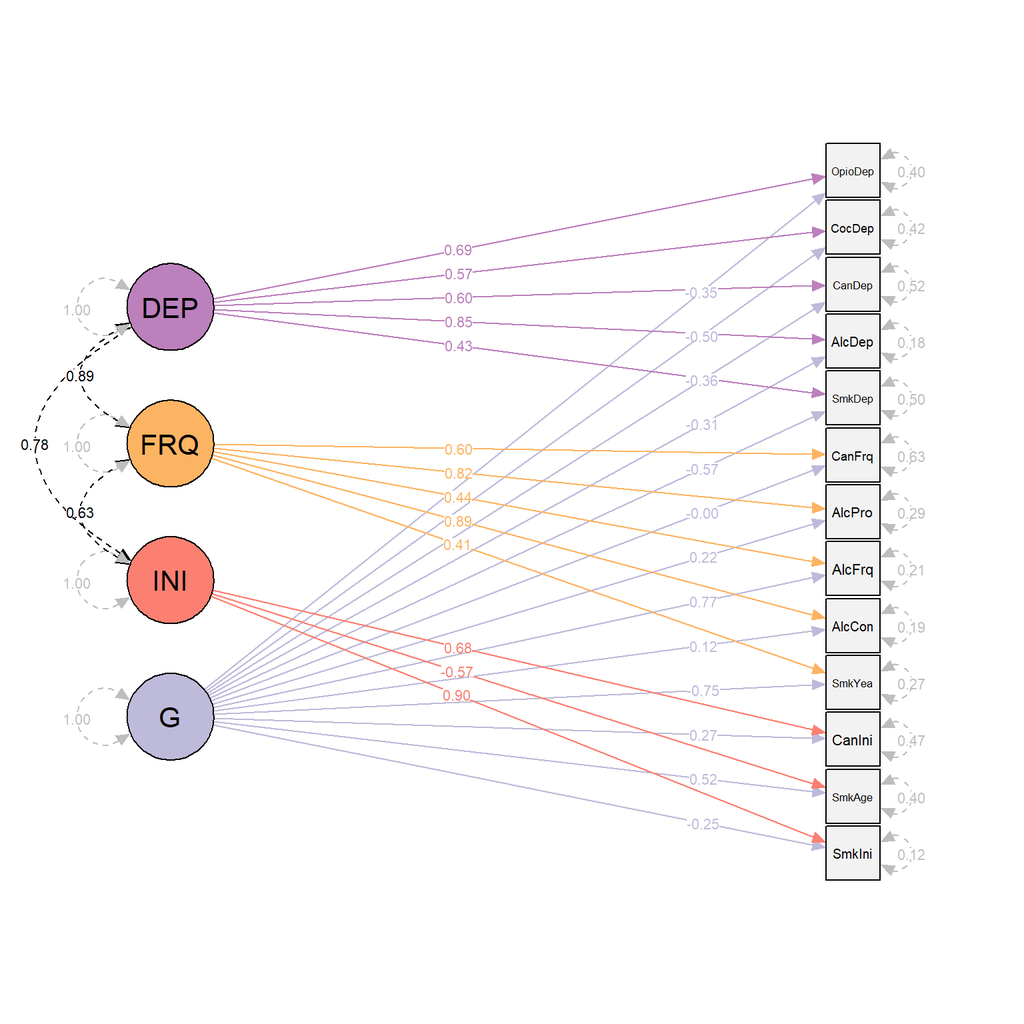

```r
semPaths(semPlotModel_GSEM(fit),
         layout="tree",
         curve = 2.5,
         whatLabels = "est",
         residuals = T,
         nodeLabels = nodelab,
         edge.color = edge.col,
         color = list(lat = c("#bebada", "#fb8072", "#fdb462", "#bc80bd"),
              man = "#f2f2f2"),
         rotation = 2,
         edge.label.position = c(rep(0.8, 13), rep(0.4, 3), rep(0.4, 5), rep(0.4, 5), rep(0.5, 29))
         )
```

### S-1 by trait type

Again, we remove the first factor because it’s captured by G. This time the model is more sensible, because the first factor was initiation, which should be the better part of the signal in G. The dependence factor does not have significant indicators, otherwise the structure looks OK. The fit is not good.

```r
CFA <- 'G =~ NA*SMKINI + SMKAGE + CANEV + PACKYE + ALCCON + ALCFRQ + ALCP + CANFL + SMKDEP + ALCDEP + CANDEP + COCDEP + OPIODEP

FRQ =~ NA*PACKYE + ALCCON + ALCFRQ + ALCP + CANFL
DEP =~ NA*SMKDEP + ALCDEP + CANDEP + COCDEP + OPIODEP

G~~1*G
FRQ~~1*FRQ
DEP~~1*DEP

G ~~ 0*FRQ + 0*DEP
'

#run the model
fit <- usermodel(ldscOut, estimation = "DWLS", model = CFA, CFIcalc = TRUE)
```

```r
fitlabel <- paste0("CFI = ", round(fit$modelfit$CFI,3), ", SRMR = ", round(fit$modelfit$SRMR,3))
kable(fitlabel)
```

| x |
| --- |
| CFI = 0.838, SRMR = 0.131 |

**Click to expand table with model parameters**

```r
kable(fit$results)
```

|  | lhs | op | rhs | Unstand_Est | Unstand_SE | STD_Genotype | STD_Genotype_SE | STD_All | p_value |
| --- | --- | --- | --- | --- | --- | --- | --- | --- | --- |
| 37 | G | =~ | SMKINI | 0.2793987 | 0.00806649411427738 | 0.8103287 | 0.0233949156347957 | 0.8103288 | 0.0000000 |
| 35 | G | =~ | SMKAGE | -0.1385494 | 0.00574943196789502 | -0.6339391 | 0.0263067519456366 | -0.6339391 | 0.0000000 |
| 30 | G | =~ | CANEV | 0.2848473 | 0.0182799424124169 | 0.4963680 | 0.0318541748986245 | 0.4963679 | 0.0000000 |
| 34 | G | =~ | PACKYE | 0.1808793 | 0.00937632055424946 | 0.5996094 | 0.0310822521299008 | 0.5996090 | 0.0000000 |
| 25 | G | =~ | ALCCON | 0.1624514 | 0.00644924727167854 | 0.6178785 | 0.0245295188592911 | 0.6178783 | 0.0000000 |
| 27 | G | =~ | ALCFRQ | 0.0030316 | 0.00640911563620646 | 0.0105372 | 0.0222765975873891 | 0.0105372 | 0.6362055 |
| 28 | G | =~ | ALCP | 0.1295973 | 0.00752967349477066 | 0.5392177 | 0.0313288425688273 | 0.5392182 | 0.0000000 |
| 31 | G | =~ | CANFL | 0.1203165 | 0.0168995757701953 | 0.5690478 | 0.079928064380232 | 0.5690475 | 0.0000000 |
| 36 | G | =~ | SMKDEP | 0.2064350 | 0.0162224711011137 | 0.5865729 | 0.0460952014951429 | 0.5865699 | 0.0000000 |
| 26 | G | =~ | ALCDEP | 0.3315579 | 0.0170135668418088 | 0.8714645 | 0.044718298579124 | 0.8714664 | 0.0000000 |
| 29 | G | =~ | CANDEP | 0.2047236 | 0.0208665012755724 | 0.6832195 | 0.069637264161747 | 0.6832193 | 0.0000000 |
| 32 | G | =~ | COCDEP | 0.3870630 | 0.0302791983194936 | 0.7095032 | 0.0555030669525278 | 0.7095030 | 0.0000000 |
| 33 | G | =~ | OPIODEP | 0.3410098 | 0.0371146169734095 | 0.7631020 | 0.0830538616205082 | 0.7631014 | 0.0000000 |
| 21 | FRQ | =~ | PACKYE | 0.1105547 | 0.0113981283458543 | 0.3664861 | 0.0377845270298258 | 0.3664858 | 0.0000000 |
| 17 | FRQ | =~ | ALCCON | -0.1387830 | 0.00850485189691613 | -0.5278579 | 0.0323479379103902 | -0.5278577 | 0.0000000 |
| 18 | FRQ | =~ | ALCFRQ | -0.2873562 | 0.0131930723011932 | -0.9987817 | 0.0458558717420912 | -0.9987815 | 0.0000000 |
| 19 | FRQ | =~ | ALCP | -0.1293871 | 0.00937253644829724 | -0.5383444 | 0.0389964820544904 | -0.5383449 | 0.0000000 |
| 20 | FRQ | =~ | CANFL | -0.0358955 | 0.016668713275994 | -0.1697736 | 0.0788363047907542 | -0.1697735 | 0.0312820 |
| 14 | DEP | =~ | SMKDEP | 0.1170560 | 0.0625803908679569 | 0.3326006 | 0.177820101475478 | 0.3325989 | 0.0614158 |
| 10 | DEP | =~ | ALCDEP | -0.0524309 | 0.0374872906187126 | -0.1378069 | 0.0985312591022896 | -0.1378072 | 0.1619234 |
| 11 | DEP | =~ | CANDEP | 0.0314122 | 0.0337047852304209 | 0.1048307 | 0.112481196434838 | 0.1048307 | 0.3513472 |
| 12 | DEP | =~ | COCDEP | 0.1378657 | 0.0777228632681825 | 0.2527111 | 0.142471544012393 | 0.2527110 | 0.0760944 |
| 13 | DEP | =~ | OPIODEP | 0.0376486 | 0.0486257258107267 | 0.0842481 | 0.108811576806575 | 0.0842480 | 0.4387809 |
| 42 | SMKINI | ~~ | SMKINI | 0.0408212 | 0.00324095510797953 | 0.3433673 | 0.0272612972901357 | 0.3433673 | 0.0000000 |
| 39 | PACKYE | ~~ | PACKYE | 0.0460600 | 0.00539173509929422 | 0.5061580 | 0.0592500698305809 | 0.5061572 | 0.0000000 |
| 40 | SMKAGE | ~~ | SMKAGE | 0.0285697 | 0.00216038649545942 | 0.5981212 | 0.0452289237653371 | 0.5981213 | 0.0000000 |
| 41 | SMKDEP | ~~ | SMKDEP | 0.0675399 | 0.0203404708166124 | 0.5453194 | 0.164223884132264 | 0.5453137 | 0.0008987 |
| 1 | ALCCON | ~~ | ALCCON | 0.0234745 | 0.00262222092842633 | 0.3395929 | 0.0379340405976047 | 0.3395927 | 0.0000000 |
| 3 | ALCFRQ | ~~ | ALCFRQ | 0.0001919 | 0.00669416413180255 | 0.0023245 | 0.080871336270432 | 0.0023245 | 0.9771281 |
| 4 | ALCP | ~~ | ALCP | 0.0242283 | 0.00332446890651596 | 0.4194277 | 0.0575517983119225 | 0.4194285 | 0.0000000 |
| 2 | ALCDEP | ~~ | ALCDEP | 0.0320708 | 0.025313157514358 | 0.2215545 | 0.174874396068082 | 0.2215555 | 0.2051692 |
| 6 | CANEV | ~~ | CANEV | 0.2481810 | 0.0180002675109527 | 0.7536192 | 0.0546590523401286 | 0.7536189 | 0.0000000 |
| 5 | CANDEP | ~~ | CANDEP | 0.0468889 | 0.0287717364912236 | 0.5222221 | 0.320442831666729 | 0.5222219 | 0.1031679 |
| 7 | CANFL | ~~ | CANFL | 0.0289400 | 0.0154955940539718 | 0.6473627 | 0.346621345946813 | 0.6473620 | 0.0618136 |
| 8 | COCDEP | ~~ | COCDEP | 0.1287900 | 0.0538914288829191 | 0.4327430 | 0.181078025810502 | 0.4327427 | 0.0168574 |
| 38 | OPIODEP | ~~ | OPIODEP | 0.0819917 | 0.0689254630876472 | 0.4105792 | 0.345151296672902 | 0.4105785 | 0.2342152 |
| 15 | FRQ | ~~ | DEP | 0.7346168 | 0.385339596105952 | 0.7346354 | 0.3853608260883 | 0.7346354 | 0.0565965 |
| 24 | G | ~~ | G | 1.0000000 |  | 1.0000000 |  | 1.0000000 | NA |
| 16 | FRQ | ~~ | FRQ | 1.0000000 |  | 1.0000000 |  | 1.0000000 | NA |
| 9 | DEP | ~~ | DEP | 1.0000000 |  | 1.0000000 |  | 1.0000000 | NA |
| 23 | G | ~~ | FRQ | 0.0000000 |  | 0.0000000 |  | 0.0000000 | NA |
| 22 | G | ~~ | DEP | 0.0000000 |  | 0.0000000 |  | 0.0000000 | NA |

### Second order by trait type

Now test the model hierarchically: this gives poor fit.

```r
bif <- 'G =~ NA*INI + FRQ + DEP

INI =~ NA*SMKINI + SMKAGE + CANEV + SMKCES
FRQ =~ NA*PACKYE + ALCCON + ALCFRQ + ALCP + CANFL
DEP =~ NA*SMKDEP + ALCDEP + CANDEP + COCDEP + OPIODEP

G ~~ 0*INI + 0*FRQ + 0*DEP
INI ~~ 0*FRQ + 0*DEP
FRQ ~~ 0*DEP

G~~1*G
INI~~1*INI
FRQ~~1*FRQ
DEP~~1*DEP
'

#run the model
fit <- usermodel(ldscOut, estimation = "DWLS", model = bif, CFIcalc = TRUE)
```

```r
fitlabel <- paste0("CFI = ", round(fit$modelfit$CFI,3), ", SRMR = ", round(fit$modelfit$SRMR,3))
kable(fitlabel)
```

| x |
| --- |
| CFI = 0.597, SRMR = 0.177 |

**Click to expand table with model parameters**

```r
kable(fit$results)
```

|  | lhs | op | rhs | Unstand_Est | Unstand_SE | STD_Genotype | STD_Genotype_SE | STD_All | p_value |
| --- | --- | --- | --- | --- | --- | --- | --- | --- | --- |
| 28 | G | =~ | INI | 1.9994517 | 0.296291957001131 | 1.9994367 | 0.296285841017814 | 0.8943768 | 0.0000000 |
| 27 | G | =~ | FRQ | 2.5323546 | 0.786098774620771 | 2.5323616 | 0.786104070037383 | 0.9301071 | 0.0012756 |
| 26 | G | =~ | DEP | 37.7209349 | 2567.60437686763 | 38.2571983 | 2678.64804706017 | 0.9996586 | 0.9882786 |
| 35 | INI | =~ | SMKINI | 0.1333755 | 0.0172010343782857 | 0.3867686 | 0.0498796458845143 | 0.8646460 | 0.0000000 |
| 33 | INI | =~ | SMKAGE | -0.0648940 | 0.00790532828507303 | -0.2967328 | 0.0361471536055673 | -0.6633652 | 0.0000000 |
| 32 | INI | =~ | CANEV | 0.1135465 | 0.0163972892259959 | 0.1978266 | 0.02856786024687 | 0.4422543 | 0.0000000 |
| 34 | INI | =~ | SMKCES | 0.0608353 | 0.00730724361230608 | 0.2263971 | 0.0271933617783597 | 0.5061254 | 0.0000000 |
| 21 | FRQ | =~ | PACKYE | 0.0692615 | 0.020464544824252 | 0.2295442 | 0.0678231910118307 | 0.6249698 | 0.0007132 |
| 17 | FRQ | =~ | ALCCON | 0.0650759 | 0.01909749802967 | 0.2474719 | 0.0726246637157847 | 0.6737806 | 0.0006555 |
| 18 | FRQ | =~ | ALCFRQ | 0.0035580 | 0.00249070552171075 | 0.0123659 | 0.00865654357142139 | 0.0336681 | 0.1531457 |
| 19 | FRQ | =~ | ALCP | 0.0514076 | 0.0149129570410985 | 0.2137265 | 0.0620006707358591 | 0.5819035 | 0.0005665 |
| 20 | FRQ | =~ | CANFL | 0.0447585 | 0.0137297824329563 | 0.2111531 | 0.0647720025204477 | 0.5748976 | 0.0011143 |
| 14 | DEP | =~ | SMKDEP | 0.0058142 | 0.3956687154295 | 0.0162887 | 1.14022441865309 | 0.6233747 | 0.9882759 |
| 10 | DEP | =~ | ALCDEP | 0.0093185 | 0.634128070684931 | 0.0241473 | 1.69027350451081 | 0.9241260 | 0.9882755 |
| 11 | DEP | =~ | CANDEP | 0.0055907 | 0.380402521040254 | 0.0184087 | 1.28843367878039 | 0.7045061 | 0.9882741 |
| 12 | DEP | =~ | COCDEP | 0.0105541 | 0.718211999991513 | 0.0190752 | 1.3352435269541 | 0.7300136 | 0.9882755 |
| 13 | DEP | =~ | OPIODEP | 0.0091456 | 0.622411655762696 | 0.0201795 | 1.41265417884419 | 0.7722773 | 0.9882765 |
| 41 | SMKINI | ~~ | SMKINI | 0.0300139 | 0.0037456310759686 | 0.2523873 | 0.031497053184016 | 0.2523873 | 0.0000000 |
| 39 | SMKCES | ~~ | SMKCES | 0.0537096 | 0.00322975111110878 | 0.7438364 | 0.0447295866681177 | 0.7438371 | 0.0000000 |
| 37 | PACKYE | ~~ | PACKYE | 0.0554831 | 0.00577518935525127 | 0.6094131 | 0.0634332280740206 | 0.6094128 | 0.0000000 |
| 38 | SMKAGE | ~~ | SMKAGE | 0.0267813 | 0.00214168539584827 | 0.5599465 | 0.0447787295270924 | 0.5599466 | 0.0000000 |
| 40 | SMKDEP | ~~ | SMKDEP | 0.0757295 | 0.0174457158658876 | 0.6114019 | 0.140846678616687 | 0.6114039 | 0.0000142 |
| 1 | ALCCON | ~~ | ALCCON | 0.0377568 | 0.00320703408815696 | 0.5460200 | 0.0463785399586261 | 0.5460197 | 0.0000000 |
| 3 | ALCFRQ | ~~ | ALCFRQ | 0.0826917 | 0.00351869171838692 | 0.9988671 | 0.0425037061188906 | 0.9988665 | 0.0000000 |
| 4 | ALCP | ~~ | ALCP | 0.0382642 | 0.00365741505838044 | 0.6613888 | 0.063217599246564 | 0.6613883 | 0.0000000 |
| 2 | ALCDEP | ~~ | ALCDEP | 0.0211349 | 0.0261203374224513 | 0.1459901 | 0.180416877648716 | 0.1459912 | 0.4184361 |
| 6 | CANEV | ~~ | CANEV | 0.2650098 | 0.018454312385098 | 0.8044106 | 0.0560162759214941 | 0.8044112 | 0.0000000 |
| 5 | CANDEP | ~~ | CANDEP | 0.0451609 | 0.0284787586788914 | 0.5036689 | 0.31761230270026 | 0.5036712 | 0.1127904 |
| 7 | CANFL | ~~ | CANFL | 0.0300815 | 0.0156805621544292 | 0.6694919 | 0.348985915771785 | 0.6694927 | 0.0550609 |
| 8 | COCDEP | ~~ | COCDEP | 0.1390049 | 0.0512296702614967 | 0.4670786 | 0.172137481961086 | 0.4670802 | 0.0066603 |
| 36 | OPIODEP | ~~ | OPIODEP | 0.0805868 | 0.069560113723427 | 0.4035851 | 0.348353196686787 | 0.4035878 | 0.2466518 |
| 25 | G | ~~ | INI | 0.0000000 |  | 0.0000000 |  | 0.0000000 | NA |
| 23 | G | ~~ | FRQ | 0.0000000 |  | 0.0000000 |  | 0.0000000 | NA |
| 22 | G | ~~ | DEP | 0.0000000 |  | 0.0000000 |  | 0.0000000 | NA |
| 30 | INI | ~~ | FRQ | 0.0000000 |  | 0.0000000 |  | 0.0000000 | NA |
| 29 | INI | ~~ | DEP | 0.0000000 |  | 0.0000000 |  | 0.0000000 | NA |
| 15 | FRQ | ~~ | DEP | 0.0000000 |  | 0.0000000 |  | 0.0000000 | NA |
| 24 | G | ~~ | G | 1.0000000 |  | 1.0000000 |  | 1.0000000 | NA |
| 31 | INI | ~~ | INI | 1.0000000 |  | 1.0000000 |  | 0.2000902 | NA |
| 16 | FRQ | ~~ | FRQ | 1.0000000 |  | 1.0000000 |  | 0.1349008 | NA |
| 9 | DEP | ~~ | DEP | 1.0000000 |  | 1.0000000 |  | 0.0006828 | NA |

# Conclusion

The best fit is achieved for the models based on the 4-factor EFA solution, with similar fit for an S-1 and second-order model. For the theory-based models, only the standard bifactor models show good fit, and only if the specific factors are allowed to correlate. This is somewhat worrying, as bifactor models often inflate overall fit estimates. This caveat is confirmed by the sometimes shaky indicator loadings, although these were sometimes also observed in the non-bifactor solutions. Overall, it seems that the theory-based bifactor models can be used for follow-up analyses, but should not be over-interpreted as constituting the ‘true’ factor structure.